# Project: Investigating Covid 19 data.

- 1- Introduction
- 2- Data and Data Sources
- 3- Data Wrangling
- 4- Data Exploration
- 4.1 Univariate Exploration
- 4.2 Univariate Exploration
- 4.3 Multivariate Exploration
- 4.4 Research Questions
- 5 -Exploratory Data Analysis
- 5.1 Behavior of Covid 19
- 5.2How Can we rely on these data to make comparisons and extract conclusions?
- 5.3 What is the effect of Population density on daily cases?
- 5.4 What is the effect of median age on daily cases?
- 5.5 What is the effect of Income Level on daily cases?
- 5.6 What is the effect of Continent on daily cases?
- 5.7 What is the effect of Vaccinations on daily cases?
- 6- Conclusions
- 7- Recommmenations

# 1- Introduction

Covid 19 pandemic has changed the world dramatically and there are a lot of unanswered questions about it. In this notebook,we will try to discover more about it using data informed strategy. Any observation - even small ones - if it is accurately interpreted,It will give us a great weapon in our war with the virus.

# 2- Data and Data Sources

### **1-** **Timeseres data:**

Four Datasets contains time series data of global confirmed, recovered, deaths and vaccinations cases for all the countries in the world till 17-6-2021.

**Source:** Johns Hopkins Coronavirus Resource Center [here.](https://coronavirus.jhu.edu/about/how-to-use-our-data)

### **2-** **Demographic data:** consists of merging two datasets including:

1- Country  
2- Population  
3- Population density (people/Km2)  
4- Total tests coducted by each country till 17-6-2021  
5- Continent  
6- Income level  
7- Median age of each country.

**Note:** Combination of data needed work with spreadsheet, manual entry and modification of data so it will be provided after pereperation.

**Sources:**

A) The United Nations Statistics Division [here.](https://unstats.un.org/unsd/demographic-social/products/dyb/index.cshtml#censusdatasets)

B) Worldometers [here.](https://www.worldometers.info/coronavirus/)

# 3- Data Wrangling

## Importing Libraries

```python
import pandas as pd
import numpy as np
import matplotlib.pyplot as plt
import seaborn as sns
%matplotlib inline
```

```python
# Loading data
confirmed_df = pd.read_csv("time_series_covid19_confirmed_global.csv")
recovered_df = pd.read_csv("time_series_covid19_recovered_global.csv")
deaths_df = pd.read_csv("time_series_covid19_deaths_global.csv")
vaccination_df = pd.read_csv("time_series_covid19_vaccine_global.csv")
Demographic_df = pd.read_csv("population_income_level_data.csv")
```

# Assessing

### 1- Timeseries dataframes

```python
confirmed_df.head()
```

|  | Province/State | Country/Region | Lat | Long | 1/22/2020 | 1/23/2020 | 1/24/2020 | 1/25/2020 | 1/26/2020 | 1/27/2020 | ... | 6/8/2021 | 6/9/2021 | 6/10/2021 | 6/11/2021 | 6/12/2021 | 6/13/2021 | 6/14/2021 | 6/15/2021 | 6/16/2021 | 6/17/2021 |
| --- | --- | --- | --- | --- | --- | --- | --- | --- | --- | --- | --- | --- | --- | --- | --- | --- | --- | --- | --- | --- | --- |
| 0 | NaN | Afghanistan | 33.93911 | 67.709953 | 0 | 0 | 0 | 0 | 0 | 0 | ... | 82326 | 84050 | 85892 | 87716 | 88740 | 89861 | 91458 | 93272 | 93288 | 96531 |
| 1 | NaN | Albania | 41.15330 | 20.168300 | 0 | 0 | 0 | 0 | 0 | 0 | ... | 132397 | 132415 | 132426 | 132437 | 132449 | 132459 | 132461 | 132469 | 132476 | 132481 |
| 2 | NaN | Algeria | 28.03390 | 1.659600 | 0 | 0 | 0 | 0 | 0 | 0 | ... | 131647 | 132034 | 132355 | 132727 | 133070 | 133388 | 133742 | 134115 | 134458 | 134840 |
| 3 | NaN | Andorra | 42.50630 | 1.521800 | 0 | 0 | 0 | 0 | 0 | 0 | ... | 13781 | 13791 | 13805 | 13813 | 13813 | 13813 | 13826 | 13828 | 13836 | 13839 |
| 4 | NaN | Angola | -11.20270 | 17.873900 | 0 | 0 | 0 | 0 | 0 | 0 | ... | 36004 | 36115 | 36325 | 36455 | 36600 | 36705 | 36790 | 36921 | 37094 | 37289 |

5 rows × 517 columns

```python
recovered_df.head()
```

|  | Province/State | Country/Region | Lat | Long | 1/22/2020 | 1/23/2020 | 1/24/2020 | 1/25/2020 | 1/26/2020 | 1/27/2020 | ... | 6/8/2021 | 6/9/2021 | 6/10/2021 | 6/11/2021 | 6/12/2021 | 6/13/2021 | 6/14/2021 | 6/15/2021 | 6/16/2021 | 6/17/2021 |
| --- | --- | --- | --- | --- | --- | --- | --- | --- | --- | --- | --- | --- | --- | --- | --- | --- | --- | --- | --- | --- | --- |
| 0 | NaN | Afghanistan | 33.93911 | 67.709953 | 0 | 0 | 0 | 0 | 0 | 0 | ... | 59569 | 59871 | 60280 | 60598 | 60939 | 61410 | 61706 | 61820 | 62397 | 62698 |
| 1 | NaN | Albania | 41.15330 | 20.168300 | 0 | 0 | 0 | 0 | 0 | 0 | ... | 129736 | 129761 | 129785 | 129807 | 129826 | 129842 | 129865 | 129879 | 129888 | 129895 |
| 2 | NaN | Algeria | 28.03390 | 1.659600 | 0 | 0 | 0 | 0 | 0 | 0 | ... | 91651 | 91894 | 92132 | 92384 | 92620 | 92852 | 93094 | 93355 | 93586 | 93831 |
| 3 | NaN | Andorra | 42.50630 | 1.521800 | 0 | 0 | 0 | 0 | 0 | 0 | ... | 13557 | 13569 | 13578 | 13591 | 13591 | 13591 | 13618 | 13626 | 13633 | 13640 |
| 4 | NaN | Angola | -11.20270 | 17.873900 | 0 | 0 | 0 | 0 | 0 | 0 | ... | 29368 | 29553 | 29960 | 30101 | 30207 | 30282 | 30359 | 30775 | 31003 | 31105 |

5 rows × 517 columns

```python
deaths_df.head()
```

|  | Province/State | Country/Region | Lat | Long | 1/22/2020 | 1/23/2020 | 1/24/2020 | 1/25/2020 | 1/26/2020 | 1/27/2020 | ... | 6/8/2021 | 6/9/2021 | 6/10/2021 | 6/11/2021 | 6/12/2021 | 6/13/2021 | 6/14/2021 | 6/15/2021 | 6/16/2021 | 6/17/2021 |
| --- | --- | --- | --- | --- | --- | --- | --- | --- | --- | --- | --- | --- | --- | --- | --- | --- | --- | --- | --- | --- | --- |
| 0 | NaN | Afghanistan | 33.93911 | 67.709953 | 0 | 0 | 0 | 0 | 0 | 0 | ... | 3251 | 3305 | 3356 | 3412 | 3449 | 3527 | 3612 | 3683 | 3683 | 3842 |
| 1 | NaN | Albania | 41.15330 | 20.168300 | 0 | 0 | 0 | 0 | 0 | 0 | ... | 2452 | 2452 | 2452 | 2453 | 2453 | 2453 | 2453 | 2454 | 2454 | 2454 |
| 2 | NaN | Algeria | 28.03390 | 1.659600 | 0 | 0 | 0 | 0 | 0 | 0 | ... | 3537 | 3544 | 3552 | 3560 | 3565 | 3571 | 3579 | 3588 | 3598 | 3605 |
| 3 | NaN | Andorra | 42.50630 | 1.521800 | 0 | 0 | 0 | 0 | 0 | 0 | ... | 127 | 127 | 127 | 127 | 127 | 127 | 127 | 127 | 127 | 127 |
| 4 | NaN | Angola | -11.20270 | 17.873900 | 0 | 0 | 0 | 0 | 0 | 0 | ... | 803 | 811 | 815 | 819 | 825 | 831 | 836 | 842 | 847 | 851 |

5 rows × 517 columns

```python
vaccination_df.head()
```

|  | Country_Region | Date | Doses_admin | People_partially_vaccinated | People_fully_vaccinated | Report_Date_String | UID | Province_State |
| --- | --- | --- | --- | --- | --- | --- | --- | --- |
| 0 | Afghanistan | 2/22/2021 | 0 | 0.0 | 0.0 | 2/22/2021 | 4.0 | NaN |
| 1 | Afghanistan | 2/23/2021 | 0 | 0.0 | 0.0 | 2/23/2021 | 4.0 | NaN |
| 2 | Afghanistan | 2/24/2021 | 0 | 0.0 | 0.0 | 2/24/2021 | 4.0 | NaN |
| 3 | Afghanistan | 2/25/2021 | 0 | 0.0 | 0.0 | 2/25/2021 | 4.0 | NaN |
| 4 | Afghanistan | 2/26/2021 | 0 | 0.0 | 0.0 | 2/26/2021 | 4.0 | NaN |

```python
# Check for null values
for df in [confirmed_df,recovered_df,deaths_df,vaccination_df]:
    print(df.isnull().sum().sort_values(ascending = False),"\n\n")
```

```
Province/State    191
Lat                 2
Long                2
12/31/2020          0
12/25/2020          0
                 ...
7/4/2020            0
7/3/2020            0
7/2/2020            0
7/1/2020            0
6/17/2021           0
Length: 517, dtype: int64


Province/State    192
Lat                 1
Long                1
12/31/2020          0
12/25/2020          0
                 ...
7/4/2020            0
7/3/2020            0
7/2/2020            0
7/1/2020            0
6/17/2021           0
Length: 517, dtype: int64


Province/State    191
Lat                 2
Long                2
12/31/2020          0
12/25/2020          0
                 ...
7/4/2020            0
7/3/2020            0
7/2/2020            0
7/1/2020            0
6/17/2021           0
Length: 517, dtype: int64


Province_State                 20174
People_partially_vaccinated     6581
People_fully_vaccinated         6581
UID                              236
Country_Region                     0
Date                               0
Doses_admin                        0
Report_Date_String                 0
dtype: int64
```

```python
# Check for duplicates
for df in [confirmed_df,recovered_df,deaths_df,vaccination_df]:
    print(df.duplicated().sum())
```

```
0
0
0
0
```

```python
#check a country with Province/State
confirmed_df[confirmed_df["Country/Region"] == "China"]
```

|  | Province/State | Country/Region | Lat | Long | 1/22/2020 | 1/23/2020 | 1/24/2020 | 1/25/2020 | 1/26/2020 | 1/27/2020 | ... | 6/8/2021 | 6/9/2021 | 6/10/2021 | 6/11/2021 | 6/12/2021 | 6/13/2021 | 6/14/2021 | 6/15/2021 | 6/16/2021 | 6/17/2021 |
| --- | --- | --- | --- | --- | --- | --- | --- | --- | --- | --- | --- | --- | --- | --- | --- | --- | --- | --- | --- | --- | --- |
| 58 | Anhui | China | 31.8257 | 117.2264 | 1 | 9 | 15 | 39 | 60 | 70 | ... | 1004 | 1004 | 1004 | 1004 | 1004 | 1004 | 1004 | 1004 | 1004 | 1004 |
| 59 | Beijing | China | 40.1824 | 116.4142 | 14 | 22 | 36 | 41 | 68 | 80 | ... | 1067 | 1067 | 1068 | 1069 | 1069 | 1070 | 1071 | 1071 | 1072 | 1072 |
| 60 | Chongqing | China | 30.0572 | 107.8740 | 6 | 9 | 27 | 57 | 75 | 110 | ... | 598 | 598 | 598 | 598 | 598 | 598 | 598 | 598 | 598 | 598 |
| 61 | Fujian | China | 26.0789 | 117.9874 | 1 | 5 | 10 | 18 | 35 | 59 | ... | 632 | 632 | 635 | 636 | 637 | 637 | 638 | 638 | 641 | 646 |
| 62 | Gansu | China | 35.7518 | 104.2861 | 0 | 2 | 2 | 4 | 7 | 14 | ... | 194 | 194 | 194 | 194 | 194 | 194 | 194 | 194 | 194 | 194 |
| 63 | Guangdong | China | 23.3417 | 113.4244 | 26 | 32 | 53 | 78 | 111 | 151 | ... | 2573 | 2582 | 2593 | 2605 | 2618 | 2625 | 2635 | 2650 | 2657 | 2666 |
| 64 | Guangxi | China | 23.8298 | 108.7881 | 2 | 5 | 23 | 23 | 36 | 46 | ... | 275 | 275 | 275 | 275 | 275 | 275 | 275 | 275 | 275 | 275 |
| 65 | Guizhou | China | 26.8154 | 106.8748 | 1 | 3 | 3 | 4 | 5 | 7 | ... | 147 | 147 | 147 | 147 | 147 | 147 | 147 | 147 | 147 | 147 |
| 66 | Hainan | China | 19.1959 | 109.7453 | 4 | 5 | 8 | 19 | 22 | 33 | ... | 188 | 188 | 188 | 188 | 188 | 188 | 188 | 188 | 188 | 188 |
| 67 | Hebei | China | 39.5490 | 116.1306 | 1 | 1 | 2 | 8 | 13 | 18 | ... | 1317 | 1317 | 1317 | 1317 | 1317 | 1317 | 1317 | 1317 | 1317 | 1317 |
| 68 | Heilongjiang | China | 47.8620 | 127.7615 | 0 | 2 | 4 | 9 | 15 | 21 | ... | 1612 | 1612 | 1612 | 1612 | 1612 | 1612 | 1612 | 1612 | 1612 | 1612 |
| 69 | Henan | China | 37.8957 | 114.9042 | 5 | 5 | 9 | 32 | 83 | 128 | ... | 1316 | 1316 | 1316 | 1316 | 1316 | 1316 | 1316 | 1316 | 1316 | 1316 |
| 70 | Hong Kong | China | 22.3000 | 114.2000 | 0 | 2 | 2 | 5 | 8 | 8 | ... | 11868 | 11872 | 11874 | 11874 | 11877 | 11877 | 11878 | 11880 | 11881 | 11881 |
| 71 | Hubei | China | 30.9756 | 112.2707 | 444 | 444 | 549 | 761 | 1058 | 1423 | ... | 68159 | 68159 | 68159 | 68159 | 68159 | 68159 | 68159 | 68159 | 68160 | 68160 |
| 72 | Hunan | China | 27.6104 | 111.7088 | 4 | 9 | 24 | 43 | 69 | 100 | ... | 1051 | 1051 | 1051 | 1051 | 1051 | 1051 | 1051 | 1051 | 1051 | 1051 |
| 73 | Inner Mongolia | China | 44.0935 | 113.9448 | 0 | 0 | 1 | 7 | 7 | 11 | ... | 390 | 390 | 390 | 390 | 390 | 393 | 393 | 393 | 393 | 393 |
| 74 | Jiangsu | China | 32.9711 | 119.4550 | 1 | 5 | 9 | 18 | 33 | 47 | ... | 729 | 729 | 730 | 734 | 735 | 736 | 736 | 738 | 739 | 739 |
| 75 | Jiangxi | China | 27.6140 | 115.7221 | 2 | 7 | 18 | 18 | 36 | 72 | ... | 937 | 937 | 937 | 937 | 937 | 937 | 937 | 937 | 937 | 937 |
| 76 | Jilin | China | 43.6661 | 126.1923 | 0 | 1 | 3 | 4 | 4 | 6 | ... | 573 | 573 | 573 | 573 | 573 | 573 | 573 | 573 | 573 | 573 |
| 77 | Liaoning | China | 41.2956 | 122.6085 | 2 | 3 | 4 | 17 | 21 | 27 | ... | 426 | 426 | 426 | 426 | 426 | 426 | 426 | 426 | 426 | 426 |
| 78 | Macau | China | 22.1667 | 113.5500 | 1 | 2 | 2 | 2 | 5 | 6 | ... | 51 | 52 | 52 | 52 | 52 | 52 | 52 | 52 | 52 | 52 |
| 79 | Ningxia | China | 37.2692 | 106.1655 | 1 | 1 | 2 | 3 | 4 | 7 | ... | 76 | 76 | 76 | 76 | 76 | 76 | 76 | 76 | 76 | 76 |
| 80 | Qinghai | China | 35.7452 | 95.9956 | 0 | 0 | 0 | 1 | 1 | 6 | ... | 18 | 18 | 18 | 18 | 18 | 18 | 18 | 18 | 18 | 18 |
| 81 | Shaanxi | China | 35.1917 | 108.8701 | 0 | 3 | 5 | 15 | 22 | 35 | ... | 618 | 620 | 620 | 621 | 622 | 622 | 622 | 622 | 622 | 622 |
| 82 | Shandong | China | 36.3427 | 118.1498 | 2 | 6 | 15 | 27 | 46 | 75 | ... | 883 | 883 | 883 | 883 | 883 | 883 | 883 | 883 | 883 | 883 |
| 83 | Shanghai | China | 31.2020 | 121.4491 | 9 | 16 | 20 | 33 | 40 | 53 | ... | 2132 | 2139 | 2141 | 2149 | 2155 | 2160 | 2165 | 2168 | 2170 | 2173 |
| 84 | Shanxi | China | 37.5777 | 112.2922 | 1 | 1 | 1 | 6 | 9 | 13 | ... | 253 | 253 | 253 | 253 | 253 | 253 | 253 | 253 | 253 | 253 |
| 85 | Sichuan | China | 30.6171 | 102.7103 | 5 | 8 | 15 | 28 | 44 | 69 | ... | 1043 | 1044 | 1046 | 1047 | 1050 | 1054 | 1055 | 1056 | 1057 | 1057 |
| 86 | Tianjin | China | 39.3054 | 117.3230 | 4 | 4 | 8 | 10 | 14 | 23 | ... | 395 | 395 | 395 | 396 | 398 | 398 | 398 | 398 | 398 | 399 |
| 87 | Tibet | China | 31.6927 | 88.0924 | 0 | 0 | 0 | 0 | 0 | 0 | ... | 1 | 1 | 1 | 1 | 1 | 1 | 1 | 1 | 1 | 1 |
| 88 | Unknown | China | NaN | NaN | 0 | 0 | 0 | 0 | 0 | 0 | ... | 0 | 0 | 0 | 0 | 0 | 0 | 0 | 0 | 0 | 0 |
| 89 | Xinjiang | China | 41.1129 | 85.2401 | 0 | 2 | 2 | 3 | 4 | 5 | ... | 980 | 980 | 980 | 980 | 980 | 980 | 980 | 980 | 980 | 980 |
| 90 | Yunnan | China | 24.9740 | 101.4870 | 1 | 2 | 5 | 11 | 16 | 26 | ... | 361 | 362 | 363 | 369 | 374 | 376 | 377 | 377 | 380 | 382 |
| 91 | Zhejiang | China | 29.1832 | 120.0934 | 10 | 27 | 43 | 62 | 104 | 128 | ... | 1368 | 1369 | 1370 | 1370 | 1372 | 1372 | 1373 | 1373 | 1373 | 1376 |

34 rows × 517 columns

# Observations

1- The first 3 dataframes has the same structure but with untidy format.</br>

2- Some countries has only (Province/State) daily records not cummulative for the whole country</br>

3- Null values in Province/State columns is related to countries records for the whole country.</br>

4- There are Null values in vaccination_df.</br>

## Solve untideness problems

- #### CODE

```python
#Create a function to deal with the first 3 dataframes as they have the same structure.
#clean confirmed_df,recovered_df,deaths_df.
def clean(df,name):
    '''
    df : name of the dataframe you want to clean
    name : whether cumulative_confirmed , cumulative_recovered or cumulative_deaths

    '''
    #sum all provinces to get the whole country records for each day
    df = df.groupby("Country/Region", as_index=0).sum()

    #drop Lat,Long as we will not use them
    df.drop(["Lat","Long"],axis = 1 , inplace= True)

    #transpose the dataframe to get all dates in one columns (solve untideness)
    df = df.transpose().reset_index()

    #set Country/Region row as our columns then drop it from dataframe
    df.columns = df.iloc[0]
    df = df.drop(0)

    #rename "Country/Region" to date to be the name of dates column
    df = df.rename(columns={"Country/Region":"date"})

    #melt our dataframe to solve untideness of country
    columns = list(df.columns)
    df = df.melt(id_vars= "date",value_vars=columns[1:],value_name= name,var_name="country")
    return df
```

```python
clean_confirmed_df = clean(confirmed_df,"cumulative_confirmed")
clean_recovered_df = clean(recovered_df,"cumulative_recovered")
clean_deaths_df = clean(deaths_df,"cumulative_deaths")
```

- ### Check

```python
clean_confirmed_df.head()
```

|  | date | country | cumulative_confirmed |
| --- | --- | --- | --- |
| 0 | 1/22/2020 | Afghanistan | 0 |
| 1 | 1/23/2020 | Afghanistan | 0 |
| 2 | 1/24/2020 | Afghanistan | 0 |
| 3 | 1/25/2020 | Afghanistan | 0 |
| 4 | 1/26/2020 | Afghanistan | 0 |

```python
clean_recovered_df.head()
```

|  | date | country | cumulative_recovered |
| --- | --- | --- | --- |
| 0 | 1/22/2020 | Afghanistan | 0 |
| 1 | 1/23/2020 | Afghanistan | 0 |
| 2 | 1/24/2020 | Afghanistan | 0 |
| 3 | 1/25/2020 | Afghanistan | 0 |
| 4 | 1/26/2020 | Afghanistan | 0 |

```python
clean_deaths_df.head()
```

|  | date | country | cumulative_deaths |
| --- | --- | --- | --- |
| 0 | 1/22/2020 | Afghanistan | 0 |
| 1 | 1/23/2020 | Afghanistan | 0 |
| 2 | 1/24/2020 | Afghanistan | 0 |
| 3 | 1/25/2020 | Afghanistan | 0 |
| 4 | 1/26/2020 | Afghanistan | 0 |

```python
for df in [clean_confirmed_df,clean_recovered_df,clean_deaths_df]:
    print(df.isnull().sum().sort_values(ascending = False),"\n\n")
```

```
date                    0
country                 0
cumulative_confirmed    0
dtype: int64


date                    0
country                 0
cumulative_recovered    0
dtype: int64


date                 0
country              0
cumulative_deaths    0
dtype: int64
```

- ## Merge the 3 dataframes
- #### CODE

```python
# merge the 3 dataframes
merged_df = pd.merge(clean_confirmed_df,clean_recovered_df,on = ["date","country"])
clean_df = pd.merge(merged_df,clean_deaths_df,on = ["date","country"])
clean_df.head()
```

|  | date | country | cumulative_confirmed | cumulative_recovered | cumulative_deaths |
| --- | --- | --- | --- | --- | --- |
| 0 | 1/22/2020 | Afghanistan | 0 | 0 | 0 |
| 1 | 1/23/2020 | Afghanistan | 0 | 0 | 0 |
| 2 | 1/24/2020 | Afghanistan | 0 | 0 | 0 |
| 3 | 1/25/2020 | Afghanistan | 0 | 0 | 0 |
| 4 | 1/26/2020 | Afghanistan | 0 | 0 | 0 |

- #### Check

```python
print("Null values:\n",clean_df.isnull().sum().sort_values(ascending = False),"\n")
print("\nDuplicates: ", clean_df.duplicated().sum())
```

```
Null values:
 date                    0
country                 0
cumulative_confirmed    0
cumulative_recovered    0
cumulative_deaths       0
dtype: int64


Duplicates:  0
```

## Vaccination dataframe

```python
vaccination_df.head()
```

|  | Country_Region | Date | Doses_admin | People_partially_vaccinated | People_fully_vaccinated | Report_Date_String | UID | Province_State |
| --- | --- | --- | --- | --- | --- | --- | --- | --- |
| 0 | Afghanistan | 2/22/2021 | 0 | 0.0 | 0.0 | 2/22/2021 | 4.0 | NaN |
| 1 | Afghanistan | 2/23/2021 | 0 | 0.0 | 0.0 | 2/23/2021 | 4.0 | NaN |
| 2 | Afghanistan | 2/24/2021 | 0 | 0.0 | 0.0 | 2/24/2021 | 4.0 | NaN |
| 3 | Afghanistan | 2/25/2021 | 0 | 0.0 | 0.0 | 2/25/2021 | 4.0 | NaN |
| 4 | Afghanistan | 2/26/2021 | 0 | 0.0 | 0.0 | 2/26/2021 | 4.0 | NaN |

## Solve untideness problems

- #### CODE

```python
#sum all provinces to get the whole country records for each day.
vaccination_df = vaccination_df.groupby(["Country_Region","Date"],as_index=0).sum()

#keep only data that we will use.
vaccination_df = vaccination_df.drop(["Doses_admin","UID"],axis = 1)

#rename columns to match that of clean_df
vaccination_df = vaccination_df.rename({"Date":"date","Country_Region":"country",
                       "People_partially_vaccinated":"partially_vaccinated",
                      "People_fully_vaccinated":"fully_vaccinated"},axis = 1)
```

- #### Check

```python
print("Null values:\n",vaccination_df.isnull().sum().sort_values(ascending = False))
vaccination_df
```

```
Null values:
 country                 0
date                    0
partially_vaccinated    0
fully_vaccinated        0
dtype: int64
```

|  | country | date | partially_vaccinated | fully_vaccinated |
| --- | --- | --- | --- | --- |
| 0 | Afghanistan | 2/22/2021 | 0.0 | 0.0 |
| 1 | Afghanistan | 2/23/2021 | 0.0 | 0.0 |
| 2 | Afghanistan | 2/24/2021 | 0.0 | 0.0 |
| 3 | Afghanistan | 2/25/2021 | 0.0 | 0.0 |
| 4 | Afghanistan | 2/26/2021 | 0.0 | 0.0 |
| ... | ... | ... | ... | ... |
| 20169 | Zimbabwe | 6/5/2021 | 684164.0 | 364340.0 |
| 20170 | Zimbabwe | 6/6/2021 | 686636.0 | 375315.0 |
| 20171 | Zimbabwe | 6/7/2021 | 686636.0 | 375315.0 |
| 20172 | Zimbabwe | 6/8/2021 | 688696.0 | 385275.0 |
| 20173 | Zimbabwe | 6/9/2021 | 689920.0 | 394063.0 |

20174 rows × 4 columns

### Merge with clean_df

```python
# Merge with yhe clean dataframe
clean_df = clean_df.merge(vaccination_df,on = ["country","date"],how = "left")
clean_df = clean_df.fillna(0)
# null happens when date is before 2/22/2021 (first date in vaccination_df)
#so replace with 0 as this means vaccination hasn't started yet
print("Null values:\n",clean_df.isnull().sum().sort_values(ascending = False))
print("\nDuplicates: ", clean_df.duplicated().sum())
clean_df
```

```
Null values:
 date                    0
country                 0
cumulative_confirmed    0
cumulative_recovered    0
cumulative_deaths       0
partially_vaccinated    0
fully_vaccinated        0
dtype: int64

Duplicates:  0
```

|  | date | country | cumulative_confirmed | cumulative_recovered | cumulative_deaths | partially_vaccinated | fully_vaccinated |
| --- | --- | --- | --- | --- | --- | --- | --- |
| 0 | 1/22/2020 | Afghanistan | 0 | 0 | 0 | 0.0 | 0.0 |
| 1 | 1/23/2020 | Afghanistan | 0 | 0 | 0 | 0.0 | 0.0 |
| 2 | 1/24/2020 | Afghanistan | 0 | 0 | 0 | 0.0 | 0.0 |
| 3 | 1/25/2020 | Afghanistan | 0 | 0 | 0 | 0.0 | 0.0 |
| 4 | 1/26/2020 | Afghanistan | 0 | 0 | 0 | 0.0 | 0.0 |
| ... | ... | ... | ... | ... | ... | ... | ... |
| 99517 | 6/13/2021 | Zimbabwe | 39959 | 37004 | 1632 | 693147.0 | 413911.0 |
| 99518 | 6/14/2021 | Zimbabwe | 40077 | 37027 | 1635 | 693568.0 | 414635.0 |
| 99519 | 6/15/2021 | Zimbabwe | 40318 | 37056 | 1637 | 693568.0 | 414635.0 |
| 99520 | 6/16/2021 | Zimbabwe | 40556 | 37075 | 1640 | 693568.0 | 414635.0 |
| 99521 | 6/17/2021 | Zimbabwe | 40927 | 37109 | 1647 | 693568.0 | 414635.0 |

99522 rows × 7 columns

## Demographic dataframe Assessing

```python
Demographic_df
```

|  | country | population | pop_density | total_tests | continent | income_level | median_age |
| --- | --- | --- | --- | --- | --- | --- | --- |
| 0 | Afghanistan | 39770634 | 59.627 | 552538 | Asia | Low income | 18.438 |
| 1 | Albania | 2874759 | 105.029 | 772270 | Europe | Upper middle income | 36.399 |
| 2 | Algeria | 44612800 | 18.411 | 230861 | Africa | Lower middle income | 28.521 |
| 3 | Andorra | 77384 | 164.394 | 193595 | Europe | High income | 46.200 |
| 4 | Angola | 33845950 | 26.363 | 608453 | Africa | Lower middle income | 16.677 |
| ... | ... | ... | ... | ... | ... | ... | ... |
| 189 | Vietnam | 98183253 | 291.000 | 6282417 | Asia | Lower middle income | 30.500 |
| 190 | West Bank and Gaza | 4817000 | 654.000 | 37529 | Asia | Lower middle income | 19.100 |
| 191 | Yemen | 30457162 | 56.492 | 92052 | Asia | Lower middle income | 20.221 |
| 192 | Zambia | 18877782 | 24.730 | 1751491 | Africa | Lower middle income | 17.592 |
| 193 | Zimbabwe | 15071278 | 38.420 | 611022 | Africa | Lower middle income | 18.668 |

194 rows × 7 columns

```python
# check for null values and duplicates
print("Null values:\n",Demographic_df.isnull().sum().sort_values(ascending = False),"\n\n")
print("\nDuplicates: ", Demographic_df.duplicated().sum())
```

```
Null values:
 country         0
population      0
pop_density     0
total_tests     0
continent       0
income_level    0
median_age      0
dtype: int64



Duplicates:  0
```

## Observations

- Clean dataframe

```python
#Add a total_tests_per_million column that will aid in the analysis
Demographic_df['total_tests_per_million'] = (Demographic_df["total_tests"]/ Demographic_df["population"])*1000000
```

```python
Demographic_df.drop("total_tests",axis = 1 , inplace = True)
Demographic_df
```

|  | country | population | pop_density | continent | income_level | median_age | total_tests_per_million |
| --- | --- | --- | --- | --- | --- | --- | --- |
| 0 | Afghanistan | 39770634 | 59.627 | Asia | Low income | 18.438 | 1.389312e+04 |
| 1 | Albania | 2874759 | 105.029 | Europe | Upper middle income | 36.399 | 2.686382e+05 |
| 2 | Algeria | 44612800 | 18.411 | Africa | Lower middle income | 28.521 | 5.174770e+03 |
| 3 | Andorra | 77384 | 164.394 | Europe | High income | 46.200 | 2.501745e+06 |
| 4 | Angola | 33845950 | 26.363 | Africa | Lower middle income | 16.677 | 1.797713e+04 |
| ... | ... | ... | ... | ... | ... | ... | ... |
| 189 | Vietnam | 98183253 | 291.000 | Asia | Lower middle income | 30.500 | 6.398665e+04 |
| 190 | West Bank and Gaza | 4817000 | 654.000 | Asia | Lower middle income | 19.100 | 7.790949e+03 |
| 191 | Yemen | 30457162 | 56.492 | Asia | Lower middle income | 20.221 | 3.022343e+03 |
| 192 | Zambia | 18877782 | 24.730 | Africa | Lower middle income | 17.592 | 9.278055e+04 |
| 193 | Zimbabwe | 15071278 | 38.420 | Africa | Lower middle income | 18.668 | 4.054215e+04 |

194 rows × 7 columns

```python
# merge with the clean dataframe and che
clean_df = clean_df.merge(Demographic_df, on = "country",how = "left")
clean_df
```

|  | date | country | cumulative_confirmed | cumulative_recovered | cumulative_deaths | partially_vaccinated | fully_vaccinated | population | pop_density | continent | income_level | median_age | total_tests_per_million |
| --- | --- | --- | --- | --- | --- | --- | --- | --- | --- | --- | --- | --- | --- |
| 0 | 1/22/2020 | Afghanistan | 0 | 0 | 0 | 0.0 | 0.0 | 39770634 | 59.627 | Asia | Low income | 18.438 | 13893.115207 |
| 1 | 1/23/2020 | Afghanistan | 0 | 0 | 0 | 0.0 | 0.0 | 39770634 | 59.627 | Asia | Low income | 18.438 | 13893.115207 |
| 2 | 1/24/2020 | Afghanistan | 0 | 0 | 0 | 0.0 | 0.0 | 39770634 | 59.627 | Asia | Low income | 18.438 | 13893.115207 |
| 3 | 1/25/2020 | Afghanistan | 0 | 0 | 0 | 0.0 | 0.0 | 39770634 | 59.627 | Asia | Low income | 18.438 | 13893.115207 |
| 4 | 1/26/2020 | Afghanistan | 0 | 0 | 0 | 0.0 | 0.0 | 39770634 | 59.627 | Asia | Low income | 18.438 | 13893.115207 |
| ... | ... | ... | ... | ... | ... | ... | ... | ... | ... | ... | ... | ... | ... |
| 99517 | 6/13/2021 | Zimbabwe | 39959 | 37004 | 1632 | 693147.0 | 413911.0 | 15071278 | 38.420 | Africa | Lower middle income | 18.668 | 40542.149113 |
| 99518 | 6/14/2021 | Zimbabwe | 40077 | 37027 | 1635 | 693568.0 | 414635.0 | 15071278 | 38.420 | Africa | Lower middle income | 18.668 | 40542.149113 |
| 99519 | 6/15/2021 | Zimbabwe | 40318 | 37056 | 1637 | 693568.0 | 414635.0 | 15071278 | 38.420 | Africa | Lower middle income | 18.668 | 40542.149113 |
| 99520 | 6/16/2021 | Zimbabwe | 40556 | 37075 | 1640 | 693568.0 | 414635.0 | 15071278 | 38.420 | Africa | Lower middle income | 18.668 | 40542.149113 |
| 99521 | 6/17/2021 | Zimbabwe | 40927 | 37109 | 1647 | 693568.0 | 414635.0 | 15071278 | 38.420 | Africa | Lower middle income | 18.668 | 40542.149113 |

99522 rows × 13 columns

```python
# check
print("Null values:\n\n",clean_df.isnull().sum().sort_values(ascending = False),"\n")
print("\nDuplicates: ", clean_df.duplicated().sum())
```

```
Null values:

 date                       0
country                    0
cumulative_confirmed       0
cumulative_recovered       0
cumulative_deaths          0
partially_vaccinated       0
fully_vaccinated           0
population                 0
pop_density                0
continent                  0
income_level               0
median_age                 0
total_tests_per_million    0
dtype: int64


Duplicates:  0
```

```python
#check datatypes
clean_df.dtypes
```

```
date                        object
country                     object
cumulative_confirmed         int64
cumulative_recovered         int64
cumulative_deaths            int64
partially_vaccinated       float64
fully_vaccinated           float64
population                   int64
pop_density                float64
continent                   object
income_level                object
median_age                 float64
total_tests_per_million    float64
dtype: object
```

```python
#change to proper data types
clean_df.date = pd.to_datetime(clean_df.date)
numeric_col = clean_df.columns[np.r_[2:8]]
clean_df[numeric_col] = clean_df[numeric_col].astype("int64")
clean_df.dtypes
```

```
date                       datetime64[ns]
country                            object
cumulative_confirmed                int64
cumulative_recovered                int64
cumulative_deaths                   int64
partially_vaccinated                int64
fully_vaccinated                    int64
population                          int64
pop_density                       float64
continent                          object
income_level                       object
median_age                        float64
total_tests_per_million           float64
dtype: object
```

## Get daily cases

#### we have only cummulative cases so lets get daily cases

```python
def daily_cases(df,column):
    """
    df: is the clean df
    column: cumulative_confirmed, cumulative_recovered, cumulative_deaths,daily_full_vaccinated
    return: daily [confirmed, recovered, deaths,full vaccinated]
    """
    daily_cases_total = pd.Series(dtype="int64")
    for i in df["country"].unique():
        df_slice = df[df["country"] == i].reset_index(drop = True)
        #get series of the day before to the end
        yesterday_cummulative_cases = df_slice[column][:].reset_index(drop =True)
        #get series from this day to the end
        today_cummulative_cases = df_slice[column][1:].reset_index(drop =True)
        #add first day rocord value to an empy series
        daily_cases_for_country = pd.Series(yesterday_cummulative_cases[0])
        #append the rest of dailt records
        daily_cases_country = daily_cases_for_country.append(today_cummulative_cases-yesterday_cummulative_cases,ignore_index=True)
        #append country daily record to the total daily record series.
        daily_cases_total = daily_cases_total.append(daily_cases_country[:-1],ignore_index=True)#excluse last value
    return daily_cases_total.astype("int64")
```

```python
clean_df["daily_confirmed"]= daily_cases(clean_df,"cumulative_confirmed")
clean_df["daily_recoverd"]= daily_cases(clean_df,"cumulative_recovered")
clean_df["daily_deaths"]= daily_cases(clean_df,"cumulative_deaths")
clean_df["daily_full_vaccinated"]= daily_cases(clean_df,"fully_vaccinated")

clean_df.sample(50)
```

|  | date | country | cumulative_confirmed | cumulative_recovered | cumulative_deaths | partially_vaccinated | fully_vaccinated | population | pop_density | continent | income_level | median_age | total_tests_per_million | daily_confirmed | daily_recoverd | daily_deaths | daily_full_vaccinated |
| --- | --- | --- | --- | --- | --- | --- | --- | --- | --- | --- | --- | --- | --- | --- | --- | --- | --- |
| 59814 | 2020-11-23 | Micronesia | 0 | 0 | 0 | 0 | 0 | 116185 | 173.163 | Oceania | Upper middle income | 26.780418 | 0.000000e+00 | 0 | 0 | 0 | 0 |
| 27087 | 2021-03-08 | Ecuador | 294618 | 256009 | 16043 | 68244 | 6228 | 17900999 | 71.038 | South America | Upper middle income | 27.930000 | 8.326390e+04 | 115 | 0 | 4 | 0 |
| 2690 | 2020-05-26 | Antigua and Barbuda | 25 | 19 | 3 | 0 | 0 | 98711 | 222.564 | North America | High income | 33.976000 | 1.691807e+05 | 0 | 0 | 0 | 0 |
| 4233 | 2020-05-30 | Australia | 7192 | 6614 | 103 | 0 | 0 | 25785033 | 3.319 | Oceania | High income | 37.875000 | 7.596788e+05 | 8 | 9 | 0 | 0 |
| 15064 | 2020-07-27 | Cabo Verde | 2328 | 1550 | 22 | 0 | 0 | 561808 | 137.962 | Africa | Lower middle income | 27.604000 | 2.909072e+05 | 21 | 103 | 0 | 0 |
| 62031 | 2021-05-07 | Montenegro | 98142 | 94655 | 1533 | 65390 | 28901 | 628143 | 46.696 | Europe | Upper middle income | 38.800000 | 6.951761e+05 | 100 | 160 | 7 | 0 |
| 6697 | 2020-02-19 | Bangladesh | 0 | 0 | 0 | 0 | 0 | 166271404 | 1265.187 | Asia | Lower middle income | 27.567000 | 3.782093e+04 | 0 | 0 | 0 | 0 |
| 53837 | 2021-05-21 | Luxembourg | 69545 | 67162 | 810 | 216030 | 93603 | 635780 | 241.690 | Europe | High income | 39.729000 | 4.745116e+06 | 80 | 168 | 1 | 2832 |
| 94119 | 2020-09-18 | United Arab Emirates | 83433 | 72790 | 403 | 0 | 0 | 10005556 | 118.306 | Asia | High income | 32.621000 | 5.448229e+06 | 865 | 673 | 1 | 0 |
| 56331 | 2021-03-11 | Maldives | 21268 | 18695 | 64 | 186930 | 0 | 549704 | 1801.807 | Asia | Upper middle income | 29.906000 | 1.735388e+06 | 124 | 161 | 0 | 0 |
| 17708 | 2020-10-14 | Chad | 1329 | 1120 | 92 | 0 | 0 | 16877855 | 13.045 | Africa | Low income | 16.554000 | 7.327412e+03 | 8 | 0 | 0 | 0 |
| 53470 | 2020-05-19 | Luxembourg | 3958 | 3718 | 109 | 0 | 0 | 635780 | 241.690 | Europe | High income | 39.729000 | 4.745116e+06 | 11 | 3 | 2 | 0 |
| 11570 | 2020-11-01 | Botswana | 6642 | 4676 | 24 | 0 | 0 | 2397276 | 4.149 | Africa | Upper middle income | 24.044000 | 5.193390e+05 | 0 | 0 | 0 | 0 |
| 86492 | 2020-11-25 | Sweden | 230514 | 0 | 6555 | 0 | 0 | 10160042 | 24.612 | Europe | High income | 41.078000 | 1.025890e+06 | 4954 | 0 | 149 | 0 |
| 26974 | 2020-11-15 | Ecuador | 180295 | 160639 | 13008 | 0 | 0 | 17900999 | 71.038 | South America | Upper middle income | 27.930000 | 8.326390e+04 | 668 | 5683 | 11 | 0 |
| 49237 | 2021-06-07 | Kyrgyzstan | 107335 | 100722 | 1852 | 37117 | 6010 | 6627792 | 34.016 | Asia | Lower middle income | 26.034000 | 1.842428e+05 | 362 | 275 | 5 | 0 |
| 91620 | 2020-11-23 | Tunisia | 89196 | 63846 | 2862 | 0 | 0 | 11937842 | 76.072 | Africa | Lower middle income | 32.835000 | 1.338532e+05 | 485 | 1597 | 41 | 0 |
| 51735 | 2021-04-01 | Liberia | 2042 | 1899 | 85 | 0 | 0 | 5171854 | 52.509 | Africa | Low income | 19.411000 | 2.204915e+04 | 0 | 0 | 0 | 0 |
| 38219 | 2020-10-05 | Haiti | 8819 | 6992 | 229 | 0 | 0 | 11536474 | 413.735 | North America | Low income | 24.008000 | 7.112745e+03 | 27 | 0 | 0 | 0 |
| 89786 | 2020-02-02 | Timor-Leste | 0 | 0 | 0 | 0 | 0 | 1342596 | 89.000 | Asia | Lower middle income | 20.795000 | 6.861483e+04 | 0 | 0 | 0 | 0 |
| 82260 | 2020-07-20 | Solomon Islands | 0 | 0 | 0 | 0 | 0 | 703057 | 24.540 | Oceania | Lower middle income | 19.889000 | 6.400619e+03 | 0 | 0 | 0 | 0 |
| 58900 | 2021-03-15 | Mauritius | 747 | 592 | 10 | 3843 | 0 | 1273807 | 626.486 | Africa | High income | 37.457000 | 2.815772e+05 | 5 | 0 | 0 | 0 |
| 66346 | 2020-07-09 | Nigeria | 30748 | 12546 | 689 | 0 | 0 | 211044851 | 226.336 | Africa | Lower middle income | 18.064000 | 1.057315e+04 | 499 | 173 | 5 | 0 |
| 16103 | 2020-08-09 | Cameroon | 18042 | 15320 | 395 | 0 | 0 | 27180255 | 56.157 | Africa | Lower middle income | 18.688000 | 6.324212e+04 | 0 | 0 | 0 | 0 |
| 34690 | 2020-12-06 | Ghana | 52274 | 51063 | 325 | 0 | 0 | 31696396 | 136.560 | Africa | Lower middle income | 21.507000 | 3.880962e+04 | 178 | 139 | 0 | 0 |
| 10369 | 2020-05-10 | Bolivia | 2556 | 273 | 118 | 0 | 0 | 11826396 | 10.775 | South America | Lower middle income | 25.560000 | 1.430189e+05 | 119 | 15 | 4 | 0 |
| 76899 | 2021-04-28 | Samoa | 3 | 2 | 0 | 0 | 0 | 199686 | 70.110 | Oceania | Upper middle income | 21.835000 | 0.000000e+00 | 0 | 0 | 0 | 0 |
| 95280 | 2021-01-31 | Uruguay | 41738 | 34683 | 436 | 0 | 0 | 3485357 | 19.848 | South America | High income | 35.760000 | 7.561082e+05 | 557 | 769 | 5 | 0 |
| 92558 | 2020-08-27 | US | 5867594 | 2101326 | 180945 | 0 | 0 | 332876117 | 36.185 | North America | High income | 38.308000 | 1.496743e+06 | 45393 | 16861 | 1115 | 0 |
| 38326 | 2021-01-20 | Haiti | 10907 | 8959 | 240 | 0 | 0 | 11536474 | 413.735 | North America | Low income | 24.008000 | 7.112745e+03 | 55 | 3 | 0 | 0 |
| 65484 | 2020-12-20 | Nicaragua | 5938 | 4225 | 163 | 0 | 0 | 6700509 | 55.049 | North America | Lower middle income | 26.464000 | 0.000000e+00 | 0 | 0 | 0 | 0 |
| 135 | 2020-06-05 | Afghanistan | 18972 | 1762 | 313 | 0 | 0 | 39770634 | 59.627 | Asia | Low income | 18.438000 | 1.389312e+04 | 915 | 177 | 9 | 0 |
| 79577 | 2020-03-24 | Seychelles | 7 | 0 | 0 | 0 | 0 | 98935 | 213.783 | Africa | High income | 34.181000 | 2.173548e+05 | 0 | 0 | 0 | 0 |
| 28941 | 2020-08-22 | Eritrea | 306 | 274 | 0 | 0 | 0 | 3593697 | 35.113 | Africa | Low income | 19.209000 | 6.592932e+03 | 0 | 0 | 0 | 0 |
| 61364 | 2020-12-04 | Mongolia | 842 | 368 | 0 | 0 | 0 | 3329106 | 2.110 | Asia | Lower middle income | 28.181000 | 9.373054e+05 | 11 | 3 | 0 | 0 |
| 86811 | 2020-05-15 | Switzerland | 30514 | 27100 | 1878 | 0 | 0 | 8715690 | 219.016 | Europe | High income | 43.053000 | 9.276167e+05 | 51 | 0 | 6 | 0 |
| 8867 | 2020-06-16 | Belize | 22 | 16 | 2 | 0 | 0 | 404572 | 17.432 | North America | Upper middle income | 25.482000 | 3.599582e+05 | 1 | 0 | 0 | 0 |
| 92635 | 2020-11-12 | US | 10660154 | 4051256 | 244355 | 0 | 0 | 332876117 | 36.185 | North America | High income | 38.308000 | 1.496743e+06 | 164750 | 54081 | 1207 | 0 |
| 30588 | 2020-12-08 | Ethiopia | 114266 | 84948 | 1766 | 0 | 0 | 117697600 | 114.964 | Africa | Low income | 19.466000 | 2.390833e+04 | 531 | 2145 | 11 | 0 |
| 92139 | 2020-11-29 | Turkey | 607628 | 400242 | 13558 | 0 | 0 | 85213922 | 109.584 | Asia | Upper middle income | 31.549000 | 6.820950e+05 | 29281 | 4015 | 185 | 0 |
| 62096 | 2020-02-14 | Morocco | 0 | 0 | 0 | 0 | 0 | 37332178 | 82.703 | Africa | Lower middle income | 29.538000 | 1.792244e+05 | 0 | 0 | 0 | 0 |
| 58487 | 2020-01-27 | Mauritius | 0 | 0 | 0 | 0 | 0 | 1273807 | 626.486 | Africa | High income | 37.457000 | 2.815772e+05 | 0 | 0 | 0 | 0 |
| 7083 | 2021-03-11 | Bangladesh | 554156 | 507920 | 8502 | 4218127 | 0 | 166271404 | 1265.187 | Asia | Lower middle income | 27.567000 | 3.782093e+04 | 1051 | 1307 | 6 | 0 |
| 52005 | 2020-08-01 | Libya | 3691 | 619 | 80 | 0 | 0 | 6961295 | 3.905 | Africa | Upper middle income | 28.817000 | 1.558489e+05 | 70 | 1 | 6 | 0 |
| 91785 | 2021-05-07 | Tunisia | 318236 | 274270 | 11277 | 340979 | 137776 | 11937842 | 76.072 | Africa | Lower middle income | 32.835000 | 1.338532e+05 | 1226 | 1765 | 69 | 13987 |
| 389 | 2021-02-14 | Afghanistan | 55492 | 48395 | 2427 | 0 | 0 | 39770634 | 59.627 | Asia | Low income | 18.438000 | 1.389312e+04 | 19 | 3 | 0 | 0 |
| 23349 | 2020-10-12 | Cyprus | 2047 | 1444 | 25 | 0 | 0 | 1215839 | 130.667 | Europe | High income | 37.250000 | 6.083737e+06 | 41 | 0 | 0 | 0 |
| 83082 | 2021-05-25 | Somalia | 14632 | 6685 | 767 | 0 | 0 | 16318531 | 25.334 | Africa | Low income | 16.683000 | 8.720822e+03 | 0 | 0 | 0 | 0 |
| 56281 | 2021-01-20 | Maldives | 14712 | 13639 | 49 | 0 | 0 | 549704 | 1801.807 | Asia | Upper middle income | 29.906000 | 1.735388e+06 | 79 | 24 | 0 | 0 |
| 99123 | 2020-05-15 | Zimbabwe | 42 | 13 | 4 | 0 | 0 | 15071278 | 38.420 | Africa | Lower middle income | 18.668000 | 4.054215e+04 | 5 | 0 | 0 | 0 |

```python
#Check
print("Null values:\n\n",clean_df.isnull().sum().sort_values(ascending = False))
print("\nDuplicates: ", clean_df.duplicated().sum())
```

```
Null values:

 date                       0
continent                  0
daily_deaths               0
daily_recoverd             0
daily_confirmed            0
total_tests_per_million    0
median_age                 0
income_level               0
pop_density                0
country                    0
population                 0
fully_vaccinated           0
partially_vaccinated       0
cumulative_deaths          0
cumulative_recovered       0
cumulative_confirmed       0
daily_full_vaccinated      0
dtype: int64

Duplicates:  0
```

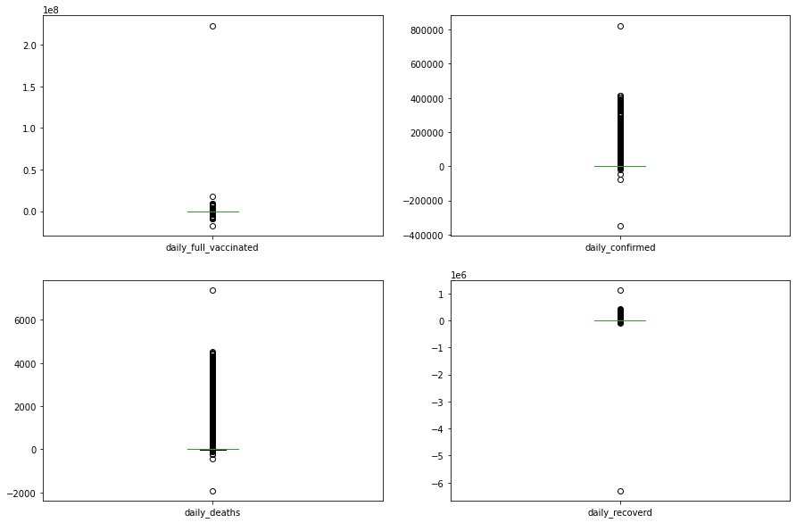

```python
# check values
plt.figure(figsize=(15,10))

plt.subplot(2,2,1)
clean_df["daily_full_vaccinated"].plot(kind = "box")

plt.subplot(2,2,2)
clean_df["daily_confirmed"].plot(kind = "box")

plt.subplot(2,2,3)
clean_df["daily_deaths"].plot(kind = "box")

plt.subplot(2,2,4)
clean_df["daily_recoverd"].plot(kind = "box")
```

```python
#check
clean_df["daily_full_vaccinated"].describe()
```

```
count    9.952200e+04
mean     7.529769e+03
std      7.208616e+05
min     -1.785655e+07
25%      0.000000e+00
50%      0.000000e+00
75%      0.000000e+00
max      2.232990e+08
Name: daily_full_vaccinated, dtype: float64
```

### There are negative values.. Lets investigate this

```python
# Check negatives
clean_df[clean_df["daily_full_vaccinated"]<0]
```

|  | date | country | cumulative_confirmed | cumulative_recovered | cumulative_deaths | partially_vaccinated | fully_vaccinated | population | pop_density | continent | income_level | median_age | total_tests_per_million | daily_confirmed | daily_recoverd | daily_deaths | daily_full_vaccinated |
| --- | --- | --- | --- | --- | --- | --- | --- | --- | --- | --- | --- | --- | --- | --- | --- | --- | --- |
| 986 | 2021-05-09 | Albania | 131723 | 117089 | 2412 | 0 | 0 | 2874759 | 105.029 | Europe | Upper middle income | 36.399 | 2.686382e+05 | 57 | 963 | 1 | -655 |
| 2007 | 2021-05-04 | Andorra | 13316 | 12818 | 127 | 0 | 0 | 77384 | 164.394 | Europe | High income | 46.200 | 2.501745e+06 | 21 | 25 | 0 | -4699 |
| 3583 | 2021-06-10 | Argentina | 4066156 | 3639402 | 83941 | 0 | 0 | 45595737 | 16.515 | South America | Upper middle income | 31.532 | 3.446379e+05 | 27628 | 30507 | 669 | -3124085 |
| 5091 | 2021-05-10 | Austria | 631896 | 605441 | 10392 | 0 | 0 | 9056001 | 109.289 | Europe | High income | 43.483 | 5.541474e+06 | 820 | 1540 | 10 | -972493 |
| 7143 | 2021-05-10 | Bangladesh | 775027 | 712277 | 11972 | 0 | 0 | 166271404 | 1265.187 | Asia | Lower middle income | 27.567 | 3.782093e+04 | 1514 | 2115 | 38 | -3496186 |
| ... | ... | ... | ... | ... | ... | ... | ... | ... | ... | ... | ... | ... | ... | ... | ... | ... | ... |
| 89736 | 2021-05-10 | Thailand | 85005 | 26873 | 421 | 0 | 0 | 69969167 | 136.624 | Asia | Upper middle income | 40.102 | 1.161893e+05 | 1630 | 0 | 22 | -513454 |
| 91787 | 2021-05-09 | Tunisia | 320813 | 277497 | 11429 | 0 | 0 | 11937842 | 76.072 | Africa | Lower middle income | 32.835 | 1.338532e+05 | 1301 | 1299 | 79 | -148943 |
| 94866 | 2021-05-10 | United Kingdom | 4437316 | 0 | 127609 | 0 | 0 | 68230263 | 280.602 | Europe | High income | 40.467 | 2.931615e+06 | 2357 | 0 | 4 | -17856550 |
| 97437 | 2021-05-16 | Vietnam | 4212 | 2668 | 37 | 954520 | 22512 | 98183253 | 291.000 | Asia | Lower middle income | 30.500 | 6.398665e+04 | 100 | 0 | 1 | -14633 |
| 99483 | 2021-05-10 | Zimbabwe | 38433 | 36208 | 1576 | 0 | 0 | 15071278 | 38.420 | Africa | Lower middle income | 18.668 | 4.054215e+04 | 14 | 145 | 0 | -158177 |

94 rows × 17 columns

```python
# check cause for United Kingdom
clean_df.iloc[94864:94869,:]
```

|  | date | country | cumulative_confirmed | cumulative_recovered | cumulative_deaths | partially_vaccinated | fully_vaccinated | population | pop_density | continent | income_level | median_age | total_tests_per_million | daily_confirmed | daily_recoverd | daily_deaths | daily_full_vaccinated |
| --- | --- | --- | --- | --- | --- | --- | --- | --- | --- | --- | --- | --- | --- | --- | --- | --- | --- |
| 94864 | 2021-05-08 | United Kingdom | 4433189 | 0 | 127603 | 35371669 | 17669379 | 68230263 | 280.602 | Europe | High income | 40.467 | 2.931615e+06 | 2051 | 0 | 5 | 438837 |
| 94865 | 2021-05-09 | United Kingdom | 4434959 | 0 | 127605 | 35472295 | 17856550 | 68230263 | 280.602 | Europe | High income | 40.467 | 2.931615e+06 | 1770 | 0 | 2 | 187171 |
| 94866 | 2021-05-10 | United Kingdom | 4437316 | 0 | 127609 | 0 | 0 | 68230263 | 280.602 | Europe | High income | 40.467 | 2.931615e+06 | 2357 | 0 | 4 | -17856550 |
| 94867 | 2021-05-11 | United Kingdom | 4439800 | 0 | 127629 | 35587348 | 18088385 | 68230263 | 280.602 | Europe | High income | 40.467 | 2.931615e+06 | 2484 | 0 | 20 | 18088385 |
| 94868 | 2021-05-12 | United Kingdom | 4442084 | 0 | 127640 | 35722461 | 18438532 | 68230263 | 280.602 | Europe | High income | 40.467 | 2.931615e+06 | 2284 | 0 | 11 | 350147 |

```python
#check for daily_confirmed
clean_df[clean_df["daily_confirmed"]<0]
```

|  | date | country | cumulative_confirmed | cumulative_recovered | cumulative_deaths | partially_vaccinated | fully_vaccinated | population | pop_density | continent | income_level | median_age | total_tests_per_million | daily_confirmed | daily_recoverd | daily_deaths | daily_full_vaccinated |
| --- | --- | --- | --- | --- | --- | --- | --- | --- | --- | --- | --- | --- | --- | --- | --- | --- | --- |
| 2728 | 2020-07-03 | Antigua and Barbuda | 68 | 23 | 3 | 0 | 0 | 98711 | 222.564 | North America | High income | 33.976 | 1.691807e+05 | -1 | 0 | 0 | 0 |
| 3038 | 2021-05-09 | Antigua and Barbuda | 1231 | 1168 | 32 | 0 | 0 | 98711 | 222.564 | North America | High income | 33.976 | 1.691807e+05 | -1 | 154 | 0 | 0 |
| 9352 | 2020-05-19 | Benin | 130 | 83 | 2 | 0 | 0 | 12427935 | 107.513 | Africa | Lower middle income | 18.781 | 4.862513e+04 | -209 | 0 | 0 | 0 |
| 18601 | 2020-06-03 | China | 84160 | 79404 | 4638 | 0 | 0 | 1439323776 | 156.110 | Asia | Upper middle income | 38.422 | 1.111633e+05 | -1 | 4 | 0 | 0 |
| 21875 | 2020-12-16 | Cote d'Ivoire | 21741 | 21364 | 133 | 0 | 0 | 27005408 | 82.951 | Africa | Upper middle income | 18.900 | 2.423914e+04 | -34 | 29 | 0 | 0 |
| ... | ... | ... | ... | ... | ... | ... | ... | ... | ... | ... | ... | ... | ... | ... | ... | ... | ... |
| 94835 | 2021-04-09 | United Kingdom | 4365486 | 0 | 127040 | 32010244 | 6991310 | 68230263 | 280.602 | Europe | High income | 40.467 | 2.931615e+06 | -4860 | 0 | 60 | 450136 |
| 94874 | 2021-05-18 | United Kingdom | 4450501 | 0 | 127691 | 36811405 | 20546452 | 68230263 | 280.602 | Europe | High income | 40.467 | 2.931615e+06 | -2364 | 0 | 7 | 259049 |
| 94986 | 2020-04-12 | Uruguay | 480 | 231 | 7 | 0 | 0 | 3485357 | 19.848 | South America | High income | 35.760 | 7.561082e+05 | -21 | 7 | 0 | 0 |
| 98185 | 2020-08-11 | Yemen | 1831 | 919 | 523 | 0 | 0 | 30457162 | 56.492 | Asia | Lower middle income | 20.221 | 3.022343e+03 | -1 | 4 | 5 | 0 |
| 99110 | 2020-05-02 | Zimbabwe | 34 | 5 | 4 | 0 | 0 | 15071278 | 38.420 | Africa | Lower middle income | 18.668 | 4.054215e+04 | -6 | 0 | 0 | 0 |

68 rows × 17 columns

```python
clean_df.iloc[94834:94837]
```

|  | date | country | cumulative_confirmed | cumulative_recovered | cumulative_deaths | partially_vaccinated | fully_vaccinated | population | pop_density | continent | income_level | median_age | total_tests_per_million | daily_confirmed | daily_recoverd | daily_deaths | daily_full_vaccinated |
| --- | --- | --- | --- | --- | --- | --- | --- | --- | --- | --- | --- | --- | --- | --- | --- | --- | --- |
| 94834 | 2021-04-08 | United Kingdom | 4370346 | 0 | 126980 | 31903366 | 6541174 | 68230263 | 280.602 | Europe | High income | 40.467 | 2.931615e+06 | 3030 | 0 | 53 | 449269 |
| 94835 | 2021-04-09 | United Kingdom | 4365486 | 0 | 127040 | 32010244 | 6991310 | 68230263 | 280.602 | Europe | High income | 40.467 | 2.931615e+06 | -4860 | 0 | 60 | 450136 |
| 94836 | 2021-04-10 | United Kingdom | 4368070 | 0 | 127080 | 32121353 | 7466540 | 68230263 | 280.602 | Europe | High income | 40.467 | 2.931615e+06 | 2584 | 0 | 40 | 475230 |

```python
#check for daily_recoverd

clean_df[clean_df["daily_recoverd"]<0]
```

|  | date | country | cumulative_confirmed | cumulative_recovered | cumulative_deaths | partially_vaccinated | fully_vaccinated | population | pop_density | continent | income_level | median_age | total_tests_per_million | daily_confirmed | daily_recoverd | daily_deaths | daily_full_vaccinated |
| --- | --- | --- | --- | --- | --- | --- | --- | --- | --- | --- | --- | --- | --- | --- | --- | --- | --- |
| 416 | 2021-03-13 | Afghanistan | 55959 | 49471 | 2454 | 8200 | 0 | 39770634 | 59.627 | Asia | Low income | 18.438 | 1.389312e+04 | 0 | -28 | 0 | 0 |
| 1088 | 2020-03-24 | Algeria | 264 | 24 | 19 | 0 | 0 | 44612800 | 18.411 | Africa | Lower middle income | 28.521 | 5.174770e+03 | 34 | -41 | 2 | 0 |
| 1090 | 2020-03-26 | Algeria | 367 | 29 | 25 | 0 | 0 | 44612800 | 18.411 | Africa | Lower middle income | 28.521 | 5.174770e+03 | 65 | -36 | 4 | 0 |
| 1150 | 2020-05-25 | Algeria | 8503 | 4747 | 609 | 0 | 0 | 44612800 | 18.411 | Africa | Lower middle income | 28.521 | 5.174770e+03 | 197 | -37 | 9 | 0 |
| 1590 | 2020-03-13 | Andorra | 1 | 0 | 0 | 0 | 0 | 77384 | 164.394 | Europe | High income | 46.200 | 2.501745e+06 | 0 | -1 | 0 | 0 |
| ... | ... | ... | ... | ... | ... | ... | ... | ... | ... | ... | ... | ... | ... | ... | ... | ... | ... |
| 97054 | 2020-04-28 | Vietnam | 270 | 222 | 0 | 0 | 0 | 98183253 | 291.000 | Asia | Lower middle income | 30.500 | 6.398665e+04 | 0 | -3 | 0 | 0 |
| 97056 | 2020-04-30 | Vietnam | 270 | 219 | 0 | 0 | 0 | 98183253 | 291.000 | Asia | Lower middle income | 30.500 | 6.398665e+04 | 0 | -3 | 0 | 0 |
| 97160 | 2020-08-12 | Vietnam | 883 | 409 | 18 | 0 | 0 | 98183253 | 291.000 | Asia | Lower middle income | 30.500 | 6.398665e+04 | 17 | -42 | 2 | 0 |
| 97545 | 2020-04-06 | West Bank and Gaza | 254 | 24 | 1 | 0 | 0 | 4817000 | 654.000 | Asia | Lower middle income | 19.100 | 7.790949e+03 | 17 | -1 | 0 | 0 |
| 97567 | 2020-04-28 | West Bank and Gaza | 343 | 71 | 2 | 0 | 0 | 4817000 | 654.000 | Asia | Lower middle income | 19.100 | 7.790949e+03 | 1 | -12 | 0 | 0 |

178 rows × 17 columns

```python
clean_df.iloc[97566:97568]
```

|  | date | country | cumulative_confirmed | cumulative_recovered | cumulative_deaths | partially_vaccinated | fully_vaccinated | population | pop_density | continent | income_level | median_age | total_tests_per_million | daily_confirmed | daily_recoverd | daily_deaths | daily_full_vaccinated |
| --- | --- | --- | --- | --- | --- | --- | --- | --- | --- | --- | --- | --- | --- | --- | --- | --- | --- |
| 97566 | 2020-04-27 | West Bank and Gaza | 342 | 83 | 2 | 0 | 0 | 4817000 | 654.0 | Asia | Lower middle income | 19.1 | 7790.948723 | 0 | 0 | 0 | 0 |
| 97567 | 2020-04-28 | West Bank and Gaza | 343 | 71 | 2 | 0 | 0 | 4817000 | 654.0 | Asia | Lower middle income | 19.1 | 7790.948723 | 1 | -12 | 0 | 0 |

```python
#check for daily_deaths
clean_df[clean_df["daily_deaths"]<0]
```

|  | date | country | cumulative_confirmed | cumulative_recovered | cumulative_deaths | partially_vaccinated | fully_vaccinated | population | pop_density | continent | income_level | median_age | total_tests_per_million | daily_confirmed | daily_recoverd | daily_deaths | daily_full_vaccinated |
| --- | --- | --- | --- | --- | --- | --- | --- | --- | --- | --- | --- | --- | --- | --- | --- | --- | --- |
| 2312 | 2020-10-08 | Angola | 5958 | 2635 | 208 | 0 | 0 | 33845950 | 26.363 | Africa | Lower middle income | 16.677 | 1.797713e+04 | 233 | 37 | -3 | 0 |
| 4235 | 2020-06-01 | Australia | 7221 | 6626 | 102 | 0 | 0 | 25785033 | 3.319 | Oceania | High income | 37.875 | 7.596788e+05 | 19 | 8 | -1 | 0 |
| 4798 | 2020-07-21 | Austria | 19827 | 17716 | 710 | 0 | 0 | 9056001 | 109.289 | Europe | High income | 43.483 | 5.541474e+06 | 84 | 57 | -1 | 0 |
| 4880 | 2020-10-11 | Austria | 55319 | 43448 | 851 | 0 | 0 | 9056001 | 109.289 | Europe | High income | 43.483 | 5.541474e+06 | 896 | 619 | -1 | 0 |
| 8425 | 2020-08-26 | Belgium | 83030 | 18331 | 9879 | 0 | 0 | 11638325 | 382.748 | Europe | High income | 41.928 | 1.261986e+06 | 583 | 40 | -117 | 0 |
| ... | ... | ... | ... | ... | ... | ... | ... | ... | ... | ... | ... | ... | ... | ... | ... | ... | ... |
| 87156 | 2021-04-25 | Switzerland | 646509 | 317600 | 10570 | 1568918 | 857397 | 8715690 | 219.016 | Europe | High income | 43.053 | 9.276167e+05 | 0 | 0 | -24 | 14873 |
| 87209 | 2021-06-17 | Switzerland | 701454 | 317600 | 10867 | 3752011 | 2341263 | 8715690 | 219.016 | Europe | High income | 43.053 | 9.276167e+05 | 194 | 0 | -1 | 0 |
| 88562 | 2020-12-13 | Tajikistan | 12704 | 12133 | 88 | 0 | 0 | 9743460 | 68.145 | Asia | Low income | 22.416 | 0.000000e+00 | 80 | 83 | -1 | 0 |
| 96544 | 2020-05-01 | Venezuela | 335 | 148 | 10 | 0 | 0 | 28358019 | 32.238 | South America | Lower middle income | 29.600 | 1.184502e+05 | 2 | 6 | -6 | 0 |
| 97167 | 2020-08-19 | Vietnam | 994 | 533 | 25 | 0 | 0 | 98183253 | 291.000 | Asia | Lower middle income | 30.500 | 6.398665e+04 | 5 | 7 | -1 | 0 |

92 rows × 17 columns

```python
clean_df.iloc[2311:2314]
```

|  | date | country | cumulative_confirmed | cumulative_recovered | cumulative_deaths | partially_vaccinated | fully_vaccinated | population | pop_density | continent | income_level | median_age | total_tests_per_million | daily_confirmed | daily_recoverd | daily_deaths | daily_full_vaccinated |
| --- | --- | --- | --- | --- | --- | --- | --- | --- | --- | --- | --- | --- | --- | --- | --- | --- | --- |
| 2311 | 2020-10-07 | Angola | 5725 | 2598 | 211 | 0 | 0 | 33845950 | 26.363 | Africa | Lower middle income | 16.677 | 17977.128726 | 0 | 0 | 0 | 0 |
| 2312 | 2020-10-08 | Angola | 5958 | 2635 | 208 | 0 | 0 | 33845950 | 26.363 | Africa | Lower middle income | 16.677 | 17977.128726 | 233 | 37 | -3 | 0 |
| 2313 | 2020-10-09 | Angola | 6031 | 2685 | 212 | 0 | 0 | 33845950 | 26.363 | Africa | Lower middle income | 16.677 | 17977.128726 | 73 | 50 | 4 | 0 |

## Observations

- #### We note some wrong inputs in cummulative values. So we need to replace wrong cummulative values - when it is smaller than that for the day before - with the last value.

### Code

```python
def correct_col(clean_df,column):
    """
    clean_df
    column: column needed to correct its values. >>

    valid for:

    cumulative_confirmed,cumulative_recovered,cumulative_deaths,fully_vaccinated,partially_vaccinated
    """
    col = []
    for j in clean_df["country"].unique():
        df = clean_df[clean_df['country']==j][column].reset_index(drop = True).copy()
        col.append(df.iloc[0])
        for i in range(len(df)-1):
            if df.iloc[i+1]>=col[-1]:
                col.append(df.iloc[i+1])
            else:
                col.append(col[-1])
    return col
```

```python
clean_df["cumulative_confirmed"] = correct_col(clean_df,"cumulative_confirmed")
clean_df["cumulative_recovered"] = correct_col(clean_df,"cumulative_recovered")
clean_df["cumulative_deaths"] = correct_col(clean_df,"cumulative_deaths")
clean_df["fully_vaccinated"] = correct_col(clean_df,"fully_vaccinated")
clean_df["partially_vaccinated"] = correct_col(clean_df,"partially_vaccinated")
```

```python
#apply daily function again
clean_df["daily_confirmed"]= daily_cases(clean_df,"cumulative_confirmed")
clean_df["daily_recoverd"]= daily_cases(clean_df,"cumulative_recovered")
clean_df["daily_deaths"]= daily_cases(clean_df,"cumulative_deaths")
clean_df["daily_full_vaccinated"]= daily_cases(clean_df,"fully_vaccinated")

#check for nulls and duplicates
print("Null values:\n",clean_df.isnull().sum().sort_values(ascending = False))
print("\nDuplicates: ", clean_df.duplicated().sum())
```

```
Null values:
 date                       0
continent                  0
daily_deaths               0
daily_recoverd             0
daily_confirmed            0
total_tests_per_million    0
median_age                 0
income_level               0
pop_density                0
country                    0
population                 0
fully_vaccinated           0
partially_vaccinated       0
cumulative_deaths          0
cumulative_recovered       0
cumulative_confirmed       0
daily_full_vaccinated      0
dtype: int64

Duplicates:  0
```

```python
#check for negative values again
clean_df[clean_df["daily_confirmed"]<0]
```

|  | date | country | cumulative_confirmed | cumulative_recovered | cumulative_deaths | partially_vaccinated | fully_vaccinated | population | pop_density | continent | income_level | median_age | total_tests_per_million | daily_confirmed | daily_recoverd | daily_deaths | daily_full_vaccinated |
| --- | --- | --- | --- | --- | --- | --- | --- | --- | --- | --- | --- | --- | --- | --- | --- | --- | --- |

```python
clean_df[clean_df["daily_recoverd"]<0]
```

|  | date | country | cumulative_confirmed | cumulative_recovered | cumulative_deaths | partially_vaccinated | fully_vaccinated | population | pop_density | continent | income_level | median_age | total_tests_per_million | daily_confirmed | daily_recoverd | daily_deaths | daily_full_vaccinated |
| --- | --- | --- | --- | --- | --- | --- | --- | --- | --- | --- | --- | --- | --- | --- | --- | --- | --- |

```python
clean_df[clean_df["daily_deaths"]<0]
```

|  | date | country | cumulative_confirmed | cumulative_recovered | cumulative_deaths | partially_vaccinated | fully_vaccinated | population | pop_density | continent | income_level | median_age | total_tests_per_million | daily_confirmed | daily_recoverd | daily_deaths | daily_full_vaccinated |
| --- | --- | --- | --- | --- | --- | --- | --- | --- | --- | --- | --- | --- | --- | --- | --- | --- | --- |

```python
clean_df[clean_df["daily_full_vaccinated"]<0]
```

|  | date | country | cumulative_confirmed | cumulative_recovered | cumulative_deaths | partially_vaccinated | fully_vaccinated | population | pop_density | continent | income_level | median_age | total_tests_per_million | daily_confirmed | daily_recoverd | daily_deaths | daily_full_vaccinated |
| --- | --- | --- | --- | --- | --- | --- | --- | --- | --- | --- | --- | --- | --- | --- | --- | --- | --- |

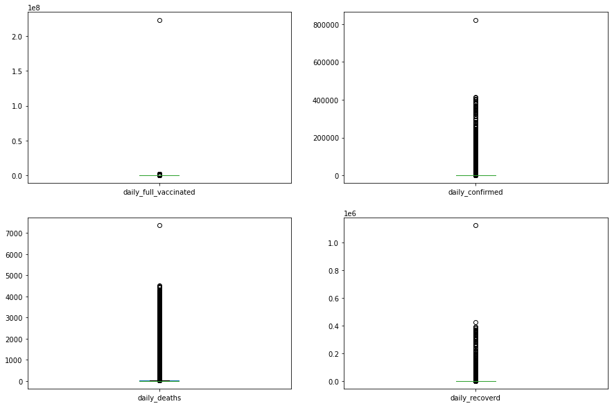

```python
# check values
plt.figure(figsize=(15,10))

plt.subplot(2,2,1)
clean_df["daily_full_vaccinated"].plot(kind = "box")

plt.subplot(2,2,2)
clean_df["daily_confirmed"].plot(kind = "box")

plt.subplot(2,2,3)
clean_df["daily_deaths"].plot(kind = "box")

plt.subplot(2,2,4)
clean_df["daily_recoverd"].plot(kind = "box")
```

```python
clean_df
```

|  | date | country | cumulative_confirmed | cumulative_recovered | cumulative_deaths | partially_vaccinated | fully_vaccinated | population | pop_density | continent | income_level | median_age | total_tests_per_million | daily_confirmed | daily_recoverd | daily_deaths | daily_full_vaccinated |
| --- | --- | --- | --- | --- | --- | --- | --- | --- | --- | --- | --- | --- | --- | --- | --- | --- | --- |
| 0 | 2020-01-22 | Afghanistan | 0 | 0 | 0 | 0 | 0 | 39770634 | 59.627 | Asia | Low income | 18.438 | 13893.115207 | 0 | 0 | 0 | 0 |
| 1 | 2020-01-23 | Afghanistan | 0 | 0 | 0 | 0 | 0 | 39770634 | 59.627 | Asia | Low income | 18.438 | 13893.115207 | 0 | 0 | 0 | 0 |
| 2 | 2020-01-24 | Afghanistan | 0 | 0 | 0 | 0 | 0 | 39770634 | 59.627 | Asia | Low income | 18.438 | 13893.115207 | 0 | 0 | 0 | 0 |
| 3 | 2020-01-25 | Afghanistan | 0 | 0 | 0 | 0 | 0 | 39770634 | 59.627 | Asia | Low income | 18.438 | 13893.115207 | 0 | 0 | 0 | 0 |
| 4 | 2020-01-26 | Afghanistan | 0 | 0 | 0 | 0 | 0 | 39770634 | 59.627 | Asia | Low income | 18.438 | 13893.115207 | 0 | 0 | 0 | 0 |
| ... | ... | ... | ... | ... | ... | ... | ... | ... | ... | ... | ... | ... | ... | ... | ... | ... | ... |
| 99517 | 2021-06-13 | Zimbabwe | 39959 | 37004 | 1632 | 693147 | 413911 | 15071278 | 38.420 | Africa | Lower middle income | 18.668 | 40542.149113 | 107 | 12 | 0 | 14857 |
| 99518 | 2021-06-14 | Zimbabwe | 40077 | 37027 | 1635 | 693568 | 414635 | 15071278 | 38.420 | Africa | Lower middle income | 18.668 | 40542.149113 | 118 | 23 | 3 | 724 |
| 99519 | 2021-06-15 | Zimbabwe | 40318 | 37056 | 1637 | 693568 | 414635 | 15071278 | 38.420 | Africa | Lower middle income | 18.668 | 40542.149113 | 241 | 29 | 2 | 0 |
| 99520 | 2021-06-16 | Zimbabwe | 40556 | 37075 | 1640 | 693568 | 414635 | 15071278 | 38.420 | Africa | Lower middle income | 18.668 | 40542.149113 | 238 | 19 | 3 | 0 |
| 99521 | 2021-06-17 | Zimbabwe | 40927 | 37109 | 1647 | 693568 | 414635 | 15071278 | 38.420 | Africa | Lower middle income | 18.668 | 40542.149113 | 371 | 34 | 7 | 0 |

99522 rows × 17 columns

## Now Lets create a copy to work with

```python
timeseries_df = clean_df.copy()
```

```python
timeseries_df.head()
```

|  | date | country | cumulative_confirmed | cumulative_recovered | cumulative_deaths | partially_vaccinated | fully_vaccinated | population | pop_density | continent | income_level | median_age | total_tests_per_million | daily_confirmed | daily_recoverd | daily_deaths | daily_full_vaccinated |
| --- | --- | --- | --- | --- | --- | --- | --- | --- | --- | --- | --- | --- | --- | --- | --- | --- | --- |
| 0 | 2020-01-22 | Afghanistan | 0 | 0 | 0 | 0 | 0 | 39770634 | 59.627 | Asia | Low income | 18.438 | 13893.115207 | 0 | 0 | 0 | 0 |
| 1 | 2020-01-23 | Afghanistan | 0 | 0 | 0 | 0 | 0 | 39770634 | 59.627 | Asia | Low income | 18.438 | 13893.115207 | 0 | 0 | 0 | 0 |
| 2 | 2020-01-24 | Afghanistan | 0 | 0 | 0 | 0 | 0 | 39770634 | 59.627 | Asia | Low income | 18.438 | 13893.115207 | 0 | 0 | 0 | 0 |
| 3 | 2020-01-25 | Afghanistan | 0 | 0 | 0 | 0 | 0 | 39770634 | 59.627 | Asia | Low income | 18.438 | 13893.115207 | 0 | 0 | 0 | 0 |
| 4 | 2020-01-26 | Afghanistan | 0 | 0 | 0 | 0 | 0 | 39770634 | 59.627 | Asia | Low income | 18.438 | 13893.115207 | 0 | 0 | 0 | 0 |

# Add some columns that will help us with the analysis

```python
# Add
timeseries_df['year'] = [d.year for d in timeseries_df.date]
#name of month
timeseries_df['month'] = [d.strftime('%b') for d in timeseries_df.date]
timeseries_df['daily_cases_per_million'] = (timeseries_df["daily_confirmed"]/ timeseries_df["population"])*1000000
timeseries_df['daily_deaths_per_million'] = (timeseries_df["daily_deaths"]/ timeseries_df["population"])*1000000
timeseries_df['daily_full_vaccinated_per_million'] = (timeseries_df["daily_full_vaccinated"]/ timeseries_df["population"])*1000000
timeseries_df['Deaths_to_confirmed_ratio'] = (timeseries_df["cumulative_deaths"]/ timeseries_df["cumulative_confirmed"]).replace(np.inf,np.nan)
timeseries_df
```

|  | date | country | cumulative_confirmed | cumulative_recovered | cumulative_deaths | partially_vaccinated | fully_vaccinated | population | pop_density | continent | ... | daily_confirmed | daily_recoverd | daily_deaths | daily_full_vaccinated | year | month | daily_cases_per_million | daily_deaths_per_million | daily_full_vaccinated_per_million | Deaths_to_confirmed_ratio |
| --- | --- | --- | --- | --- | --- | --- | --- | --- | --- | --- | --- | --- | --- | --- | --- | --- | --- | --- | --- | --- | --- |
| 0 | 2020-01-22 | Afghanistan | 0 | 0 | 0 | 0 | 0 | 39770634 | 59.627 | Asia | ... | 0 | 0 | 0 | 0 | 2020 | Jan | 0.000000 | 0.000000 | 0.000000 | NaN |
| 1 | 2020-01-23 | Afghanistan | 0 | 0 | 0 | 0 | 0 | 39770634 | 59.627 | Asia | ... | 0 | 0 | 0 | 0 | 2020 | Jan | 0.000000 | 0.000000 | 0.000000 | NaN |
| 2 | 2020-01-24 | Afghanistan | 0 | 0 | 0 | 0 | 0 | 39770634 | 59.627 | Asia | ... | 0 | 0 | 0 | 0 | 2020 | Jan | 0.000000 | 0.000000 | 0.000000 | NaN |
| 3 | 2020-01-25 | Afghanistan | 0 | 0 | 0 | 0 | 0 | 39770634 | 59.627 | Asia | ... | 0 | 0 | 0 | 0 | 2020 | Jan | 0.000000 | 0.000000 | 0.000000 | NaN |
| 4 | 2020-01-26 | Afghanistan | 0 | 0 | 0 | 0 | 0 | 39770634 | 59.627 | Asia | ... | 0 | 0 | 0 | 0 | 2020 | Jan | 0.000000 | 0.000000 | 0.000000 | NaN |
| ... | ... | ... | ... | ... | ... | ... | ... | ... | ... | ... | ... | ... | ... | ... | ... | ... | ... | ... | ... | ... | ... |
| 99517 | 2021-06-13 | Zimbabwe | 39959 | 37004 | 1632 | 693147 | 413911 | 15071278 | 38.420 | Africa | ... | 107 | 12 | 0 | 14857 | 2021 | Jun | 7.099597 | 0.000000 | 985.782360 | 0.040842 |
| 99518 | 2021-06-14 | Zimbabwe | 40077 | 37027 | 1635 | 693568 | 414635 | 15071278 | 38.420 | Africa | ... | 118 | 23 | 3 | 724 | 2021 | Jun | 7.829462 | 0.199054 | 48.038395 | 0.040796 |
| 99519 | 2021-06-15 | Zimbabwe | 40318 | 37056 | 1637 | 693568 | 414635 | 15071278 | 38.420 | Africa | ... | 241 | 29 | 2 | 0 | 2021 | Jun | 15.990681 | 0.132703 | 0.000000 | 0.040602 |
| 99520 | 2021-06-16 | Zimbabwe | 40556 | 37075 | 1640 | 693568 | 414635 | 15071278 | 38.420 | Africa | ... | 238 | 19 | 3 | 0 | 2021 | Jun | 15.791627 | 0.199054 | 0.000000 | 0.040438 |
| 99521 | 2021-06-17 | Zimbabwe | 40927 | 37109 | 1647 | 693568 | 414635 | 15071278 | 38.420 | Africa | ... | 371 | 34 | 7 | 0 | 2021 | Jun | 24.616360 | 0.464460 | 0.000000 | 0.040242 |

99522 rows × 23 columns

### We have Nan values Deaths_to_confirmed_ratio column related to the days before the first wave. However ,lets keep them so as not to affect the calculation of mean Deaths_to_confirmed_ratio.

# IMPORTANT NOTES

**1-** There are many variables that may affect the daily covid cases,like test rates,median age,income level,population,population density,etc...therefore comparisons will be hard.

For example, countries with high test rates can get higher numbers of daily cases than others. If we try to find the effect of another variable like median age on number of daily cases, we can be misleaded and get inaccurate insights due to interference with the effect of the test rate.

**2-** To get accurate analysis we need to see the effect of one variable making other variables constant as much as possible.

**3-** So, I will cut some numeric variables like,pop_density,median_age,etc.. into two levels based on their median, and our comparisons will be based on these levels. This won't solve the problem completely but it will help see more clearly through the data.

**4-** Also, daily confirmed cases may be affected by population size.

For ex: high population size will give high number of cases than other country with small population even if virus spreading in small population countries is higher. To track the panademic spread,wave strength of different countries and when we need to exclude this effect for investigating the effect other parameters on the panademic spread, we need to use daily cases per one million of the population instead. This will exclude population size effect.

# Median split

### 1- Total Tests Per Million

```python
test_per_million= timeseries_df.groupby(["country","total_tests_per_million"],as_index = False).mean()["total_tests_per_million"]
test_per_million.describe()
```

```
count    1.940000e+02
mean     5.882657e+05
std      1.191518e+06
min      0.000000e+00
25%      3.924275e+04
50%      2.036014e+05
75%      6.517530e+05
max      1.110910e+07
Name: total_tests_per_million, dtype: float64
```

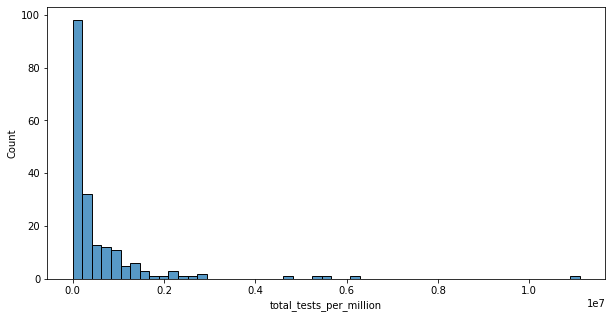

```python
#tests_per_million distribution
plt.figure(figsize=(10,5))
sns.histplot(test_per_million);
```

```python
#Add_two levels based on median
timeseries_df["test_per_million_level"] = pd.cut(timeseries_df["total_tests_per_million"],
                                        bins =[0,2e5,12e6],include_lowest =True,
                                    labels=["Low","High"])
```

### 2- Median Age

```python
median_age= timeseries_df.groupby(["country","median_age"],as_index = False).mean()["median_age"]
median_age.describe()
```

```
count    194.000000
mean      30.310169
std        9.482776
min        0.000000
25%       21.960000
50%       29.710500
75%       38.298000
max       55.000000
Name: median_age, dtype: float64
```

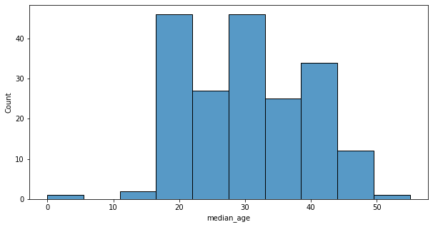

```python
#median_age distribution
plt.figure(figsize=(10,5))
sns.histplot(timeseries_df.groupby(["country","median_age"],as_index = False).mean()["median_age"]);
```

```python
#Add_levels

timeseries_df["median_age_level"] = pd.cut(timeseries_df["median_age"], bins =[0,30,55],
                                    include_lowest =True,
                                labels=["Low","High"])
```

### 3- Population Density

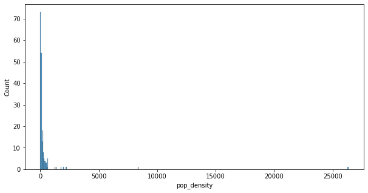

```python
#pop_density distribution
plt.figure(figsize=(10,5))
sns.histplot(timeseries_df.groupby(["country","pop_density"],as_index = False).mean()["pop_density"]);
```

```python
pop_density_group = timeseries_df.groupby(["country","pop_density"],as_index = False).mean()["pop_density"]
pop_density_group.describe()
```

```
count      194.000000
mean       353.414485
std       1987.725949
min          2.110000
25%         35.381000
50%         87.744500
75%        211.726000
max      26338.255000
Name: pop_density, dtype: float64
```

```python
timeseries_df["pop_density_level"] = pd.cut(timeseries_df["pop_density"],
                                            bins =[0,88,27000],
                                            labels=["Low","High"])
```

```python
timeseries_df
```

|  | date | country | cumulative_confirmed | cumulative_recovered | cumulative_deaths | partially_vaccinated | fully_vaccinated | population | pop_density | continent | ... | daily_full_vaccinated | year | month | daily_cases_per_million | daily_deaths_per_million | daily_full_vaccinated_per_million | Deaths_to_confirmed_ratio | test_per_million_level | median_age_level | pop_density_level |
| --- | --- | --- | --- | --- | --- | --- | --- | --- | --- | --- | --- | --- | --- | --- | --- | --- | --- | --- | --- | --- | --- |
| 0 | 2020-01-22 | Afghanistan | 0 | 0 | 0 | 0 | 0 | 39770634 | 59.627 | Asia | ... | 0 | 2020 | Jan | 0.000000 | 0.000000 | 0.000000 | NaN | Low | Low | Low |
| 1 | 2020-01-23 | Afghanistan | 0 | 0 | 0 | 0 | 0 | 39770634 | 59.627 | Asia | ... | 0 | 2020 | Jan | 0.000000 | 0.000000 | 0.000000 | NaN | Low | Low | Low |
| 2 | 2020-01-24 | Afghanistan | 0 | 0 | 0 | 0 | 0 | 39770634 | 59.627 | Asia | ... | 0 | 2020 | Jan | 0.000000 | 0.000000 | 0.000000 | NaN | Low | Low | Low |
| 3 | 2020-01-25 | Afghanistan | 0 | 0 | 0 | 0 | 0 | 39770634 | 59.627 | Asia | ... | 0 | 2020 | Jan | 0.000000 | 0.000000 | 0.000000 | NaN | Low | Low | Low |
| 4 | 2020-01-26 | Afghanistan | 0 | 0 | 0 | 0 | 0 | 39770634 | 59.627 | Asia | ... | 0 | 2020 | Jan | 0.000000 | 0.000000 | 0.000000 | NaN | Low | Low | Low |
| ... | ... | ... | ... | ... | ... | ... | ... | ... | ... | ... | ... | ... | ... | ... | ... | ... | ... | ... | ... | ... | ... |
| 99517 | 2021-06-13 | Zimbabwe | 39959 | 37004 | 1632 | 693147 | 413911 | 15071278 | 38.420 | Africa | ... | 14857 | 2021 | Jun | 7.099597 | 0.000000 | 985.782360 | 0.040842 | Low | Low | Low |
| 99518 | 2021-06-14 | Zimbabwe | 40077 | 37027 | 1635 | 693568 | 414635 | 15071278 | 38.420 | Africa | ... | 724 | 2021 | Jun | 7.829462 | 0.199054 | 48.038395 | 0.040796 | Low | Low | Low |
| 99519 | 2021-06-15 | Zimbabwe | 40318 | 37056 | 1637 | 693568 | 414635 | 15071278 | 38.420 | Africa | ... | 0 | 2021 | Jun | 15.990681 | 0.132703 | 0.000000 | 0.040602 | Low | Low | Low |
| 99520 | 2021-06-16 | Zimbabwe | 40556 | 37075 | 1640 | 693568 | 414635 | 15071278 | 38.420 | Africa | ... | 0 | 2021 | Jun | 15.791627 | 0.199054 | 0.000000 | 0.040438 | Low | Low | Low |
| 99521 | 2021-06-17 | Zimbabwe | 40927 | 37109 | 1647 | 693568 | 414635 | 15071278 | 38.420 | Africa | ... | 0 | 2021 | Jun | 24.616360 | 0.464460 | 0.000000 | 0.040242 | Low | Low | Low |

99522 rows × 26 columns

```python
timeseries_df.columns
```

```
Index(['date', 'country', 'cumulative_confirmed', 'cumulative_recovered',
       'cumulative_deaths', 'partially_vaccinated', 'fully_vaccinated',
       'population', 'pop_density', 'continent', 'income_level', 'median_age',
       'total_tests_per_million', 'daily_confirmed', 'daily_recoverd',
       'daily_deaths', 'daily_full_vaccinated', 'year', 'month',
       'daily_cases_per_million', 'daily_deaths_per_million',
       'daily_full_vaccinated_per_million', 'Deaths_to_confirmed_ratio',
       'test_per_million_level', 'median_age_level', 'pop_density_level'],
      dtype='object')
```

# 4- Data Exploration

## 4.1 Univariate Explorations

### Population density exploration

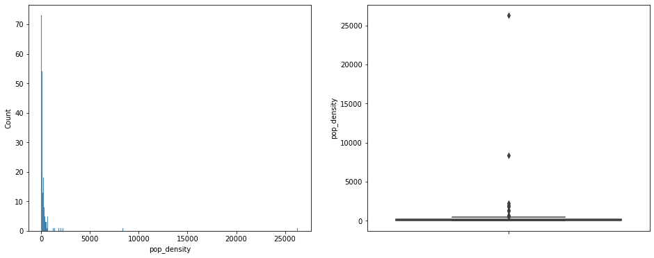

```python
#1- get data for each country avoid repeatition
pop_density = timeseries_df.groupby(["country","pop_density"],as_index = False).sum()["pop_density"]
plt.subplots(figsize=(16,6))

plt.subplot(1,2,1)
sns.histplot(x= pop_density);
plt.subplot(1,2,2)
sns.boxplot(y= pop_density);
```

### Median age exploration

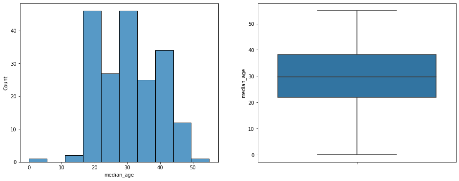

```python
# median age exploration

#1- get data for each country avoid repeatition
median_age = timeseries_df.groupby(["country","median_age"],as_index = False).sum()["median_age"]
plt.subplots(figsize=(16,6))

plt.subplot(1,2,1)
sns.histplot(x= median_age);
plt.subplot(1,2,2)
sns.boxplot(y= median_age);
```

# Note:

1- There are some outliers in population density distribution.

2- No outliers werw found in median age distribution but there is a wrong value of (0) should be removed.

```python
# Replace zero with nan value instead of dropping this observation
# So as to make use of other attributes of it.
timeseries_df["median_age"].replace(0,np.nan,inplace = True)
```

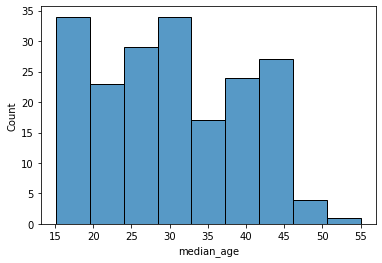

```python
# Check
median_age = timeseries_df.groupby(["country","median_age"],as_index = False).sum()["median_age"]
sns.histplot(x= median_age);
```

### Total_tests_per_million exploration

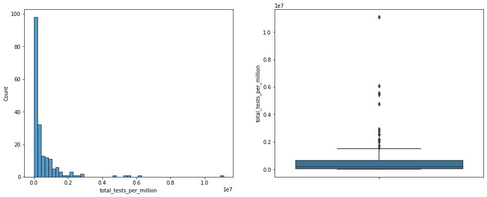

```python
# total_tests_per_million exploration
tests = timeseries_df.groupby(["country","total_tests_per_million"],as_index = False).sum()["total_tests_per_million"]

plt.subplots(figsize=(16,6))

plt.subplot(1,2,1)
sns.histplot(x= tests);
plt.subplot(1,2,2)
sns.boxplot(y=tests);
```

### Note:

1- There are some outliers.

2- Varaition between countries in testing rate is not small at all. This should be taken into consideration in the analysis.

# 4.2 Bivariate Explorations

### Explore average daily cases per million distribution in each month

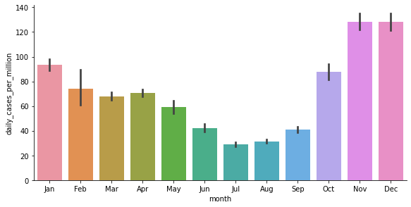

```python
# average Daily_cases_per_million distribution in each month for the the whole world?
sns.catplot(x ="month",y = "daily_cases_per_million",data =timeseries_df,kind = "bar",height=4,aspect=2);
```

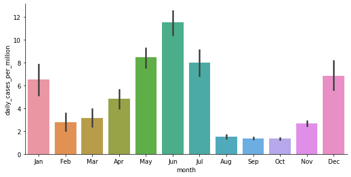

```python
# average Daily_cases_per_million distribution in each month for Egypt?
sns.catplot(x ="month",y = "daily_cases_per_million",data = timeseries_df[timeseries_df["country"] == "Egypt"],
            kind = "bar",height=4,aspect=2)
```

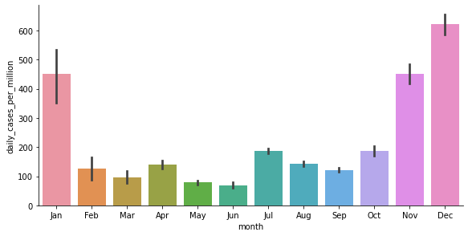

```python
# average Daily_cases_per_million distribution in each month for US?
sns.catplot(x ="month",y = "daily_cases_per_million",data = timeseries_df[timeseries_df["country"] == "US"],
            kind = "bar",height=4,aspect=2);
```

# Note:

The Cases distribution based on months follow different patterns for different countries and the whole world data can't be generalized.

### TOTAL Tests per million for different countries.

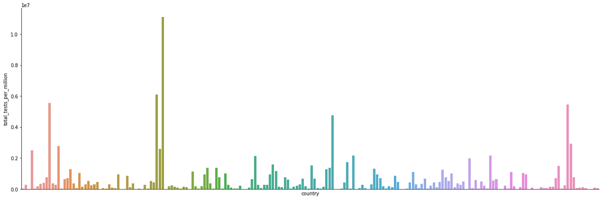

```python
# TOTAL Tests per million for different countries.
plt.figure(figsize=(16,6))
sns.catplot(x="country",y= "total_tests_per_million",data = timeseries_df,
            kind = "bar", height=6,aspect=3);
plt.xticks([]);#remove countries as they are too many.
```

### Empahsis of that :

Big Varaition between countries in testing rate.

## Pairplot for effect of population density, median age and vaccination on Daily cases per million

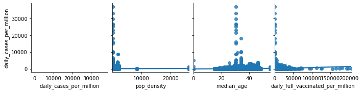

```python
sns.pairplot(y_vars="daily_cases_per_million",data = timeseries_df[["daily_cases_per_million","pop_density","median_age","daily_full_vaccinated_per_million"]],
             kind = "reg");
```

## Note:

This can't give us a clear idea. There are outliers that should be removed during analysis, but we can't remove it from the dataset at all.Some observations could have outliers in only one attributte and all other attributes don't form outliers so removing outliers will be based on the reasearch question.

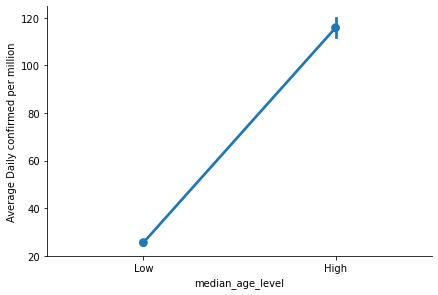

```python
sns.catplot(y = "daily_cases_per_million",
            x= "median_age_level",
            data = timeseries_df,
            kind = "point",
            split = True,
           margin_titles=True,height=4,aspect=1.5);
plt.ylabel("Average Daily confirmed per million");
```

## Note:

High median age countries experience higher avearge daily confirmed cases per million

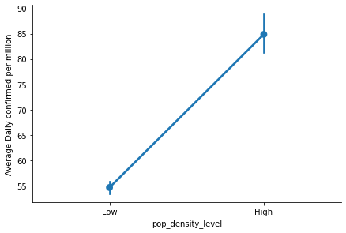

```python
sns.catplot(y = "daily_cases_per_million",
            x= "pop_density_level",
            data = timeseries_df,
            kind = "point",
            split = True,
           margin_titles=True,height=4,aspect=1.5);
plt.ylabel("Average Daily confirmed per million");
```

## Note:

High population density countries experience higher avearge daily confirmed cases per million

# Average Cases in each Continent

```python
continent_df = timeseries_df.groupby("continent",as_index = False).sum()[["continent","daily_deaths","daily_confirmed","population"]].drop(6)
continent_df["total_cases_per_million"] = (continent_df["daily_confirmed"]/continent_df["population"])*1000000
continent_df["total_deaths_per_million"] = (continent_df["daily_deaths"]/continent_df["population"])*1000000
continent_df["Deaths_to_confirmed_ratio"] = (continent_df["daily_deaths"]/continent_df["daily_confirmed"])
continent_df.rename(columns = {"daily_deaths":"total_deaths","daily_confirmed":"total_confirmed"},inplace =True)
continent_df
```

|  | continent | total_deaths | total_confirmed | population | total_cases_per_million | total_deaths_per_million | Deaths_to_confirmed_ratio |
| --- | --- | --- | --- | --- | --- | --- | --- |
| 0 | Africa | 136278 | 5131055 | 701231849379 | 7.317202 | 0.194341 | 0.026559 |
| 1 | Asia | 869188 | 58358656 | 2442506200119 | 23.892941 | 0.355859 | 0.014894 |
| 2 | Europe | 980272 | 43368658 | 319083295464 | 135.916416 | 3.072151 | 0.022603 |
| 3 | North America | 894079 | 39352698 | 303754076217 | 129.554469 | 2.943430 | 0.022720 |
| 4 | Oceania | 1110 | 51392 | 21715264350 | 2.366630 | 0.051116 | 0.021599 |
| 5 | South America | 960174 | 31207198 | 222578994366 | 140.207292 | 4.313857 | 0.030768 |

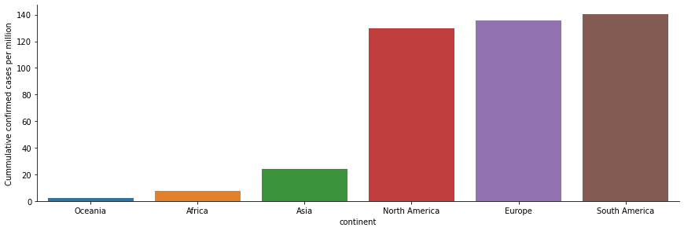

```python
continent_df.sort_values(by="total_cases_per_million",inplace=True)
sns.catplot(y = "total_cases_per_million",
            x= "continent",
            data = continent_df,
            kind = "bar",
           margin_titles=True,height=4,aspect=3,order =continent_df["continent"]);
plt.ylabel("Cummulative confirmed cases per million");
```

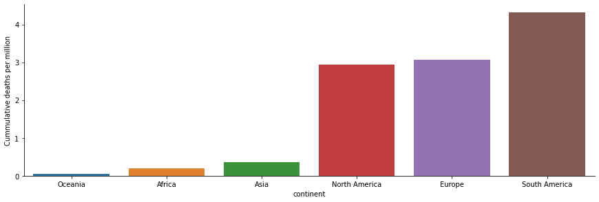

```python
continent_df.sort_values(by="total_deaths_per_million",inplace=True)
sns.catplot(y = "total_deaths_per_million",
            x= "continent",
            data = continent_df,
            kind = "bar",
           margin_titles=True,height=4,aspect=3,order =continent_df["continent"]);
plt.ylabel("Cummulative deaths per million");
```

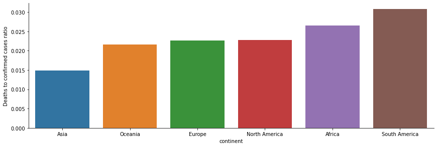

```python
continent_df.sort_values(by="Deaths_to_confirmed_ratio",inplace=True)
sns.catplot(y = "Deaths_to_confirmed_ratio",
            x= "continent",
            data = continent_df,
            kind = "bar",
           margin_titles=True,height=4,aspect=3,order =continent_df["continent"]);
plt.ylabel("Deaths to confirmed cases ratio");
```

## Note:

1- we can see that even Africa has lower cases per million and deaths per million but has the second highest deaths to confirmed ratio. This can reflect quality of the heath care system of Africa.

2- South America is the most suffering continent with highest cummulative cases, deaths and deaths to confirmed ratio.

3- Europe and North America reflect better heath care systems with their low death to confirmed ratios compared to their very high cases per million.

# 4.3 Multivariate Explorations

# Take account of testing rate

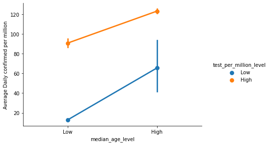

```python
sns.catplot(y = "daily_cases_per_million",
            hue= "test_per_million_level",
            x= "median_age_level",
            data = timeseries_df,
            kind = "point",
            split = True,
           margin_titles=True,height=4,aspect=1.5);
plt.ylabel("Average Daily confirmed per million");
```

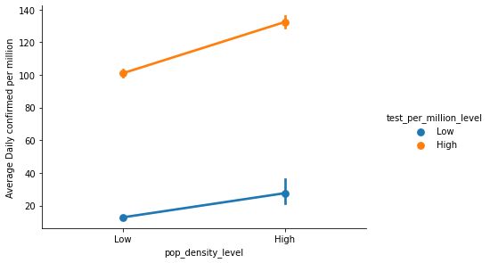

```python
sns.catplot(y = "daily_cases_per_million",
            hue= "test_per_million_level",
            x= "pop_density_level",
            data = timeseries_df,
            kind = "point",
            split = True,
           margin_titles=True,height=4,aspect=1.5);
plt.ylabel("Average Daily confirmed per million");
```

## Split plots base on Population Density and Median Age Levels

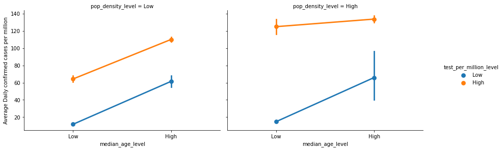

```python
g = sns.catplot(col = "pop_density_level",
            y = "daily_cases_per_million",
            hue= "test_per_million_level",
            x= "median_age_level",
            data = timeseries_df,
            kind = "point",
            split = True,
           margin_titles=True,height=4,aspect=1.5);
g.set_ylabels('Average Daily confirmed cases per million', fontsize=10);
```

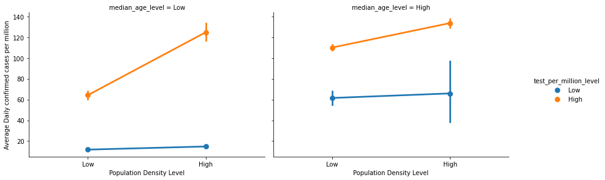

```python
g = sns.catplot(col = "median_age_level",
            y = "daily_cases_per_million",
            hue= "test_per_million_level",
            x= "pop_density_level",
            data = timeseries_df,
            kind = "point",
            split = True,
           margin_titles=True,height=4,aspect=1.5);
g.set_ylabels('Average Daily confirmed cases per million', fontsize=10);
g.set_xlabels('Population Density Level', fontsize=10);
```

# Note:

1- As noticed befor high test rates will lead to higher cases discovery.

2- Dividing our data on different variables' levels can let us be more specific when taking about the effect of some variable on average daily cases per million and can give us more accurate insights from the general overview of the data.

# Our Research Questions Will Be:

1- What is the behavior of Covid19?

- Are Covid waves till now repeating with a pattern,ie are they coming in specific months?
- Does the waves' strength change or not?

2- How Can we rely on these data to make comparisons and extract conclusions?

3- What is the effect of Population density on daily cases?

4- What is the effect of median age on daily cases?

5- What is the effect of Income Level on daily cases?

6- What is the effect of Continent on daily cases?

7- What is the effect of Vaccinations on daily cases?

#### Before starting to answer our questions lets create parameters dataframe

It will contain all countries with their average parameters through the panademic like average daily cases,deaths,etc..

```python
parameter_df = timeseries_df.groupby(['country', 'continent', 'income_level',
        'test_per_million_level', 'median_age_level','pop_density_level'],as_index = False).mean()
parameter_df = parameter_df.dropna().reset_index(drop = True)
parameter_df
```

|  | country | continent | income_level | test_per_million_level | median_age_level | pop_density_level | cumulative_confirmed | cumulative_recovered | cumulative_deaths | partially_vaccinated | ... | total_tests_per_million | daily_confirmed | daily_recoverd | daily_deaths | daily_full_vaccinated | year | daily_cases_per_million | daily_deaths_per_million | daily_full_vaccinated_per_million | Deaths_to_confirmed_ratio |
| --- | --- | --- | --- | --- | --- | --- | --- | --- | --- | --- | --- | --- | --- | --- | --- | --- | --- | --- | --- | --- | --- |
| 0 | Afghanistan | Asia | Low income | Low | Low | Low | 36255.269006 | 28457.382066 | 1426.074074 | 49528.532164 | ... | 1.389312e+04 | 188.169591 | 122.218324 | 7.489279 | 345.547758 | 2020.327485 | 4.731370 | 0.188312 | 8.688515 | 0.034584 |
| 1 | Albania | Europe | Upper middle income | High | High | High | 43439.610136 | 31987.192982 | 823.672515 | 34796.514620 | ... | 2.686382e+05 | 258.247563 | 253.206628 | 4.783626 | 685.093567 | 2020.327485 | 89.832770 | 1.664009 | 238.313392 | 0.025465 |
| 2 | Algeria | Africa | Lower middle income | Low | Low | Low | 58843.058480 | 40354.124756 | 1757.555556 | 53606.237817 | ... | 5.174770e+03 | 262.846004 | 182.906433 | 7.027290 | 0.000000 | 2020.327485 | 5.891717 | 0.157517 | 0.000000 | 0.044140 |
| 3 | Andorra | Europe | High income | High | High | High | 5149.401559 | 4717.337232 | 67.276803 | 3806.576998 | ... | 2.501745e+06 | 26.976608 | 26.588694 | 0.247563 | 32.000000 | 2020.327485 | 348.607053 | 3.199154 | 413.522175 | 0.027189 |
| 4 | Angola | Africa | Lower middle income | Low | Low | Low | 10618.824561 | 8275.539961 | 256.953216 | 78015.087719 | ... | 1.797713e+04 | 72.688109 | 60.633528 | 1.658869 | 959.582846 | 2020.327485 | 2.147616 | 0.049012 | 28.351482 | 0.038636 |
| ... | ... | ... | ... | ... | ... | ... | ... | ... | ... | ... | ... | ... | ... | ... | ... | ... | ... | ... | ... | ... | ... |
| 189 | Vietnam | Asia | Lower middle income | Low | High | High | 1549.081871 | 1083.148148 | 21.937622 | 106882.005848 | ... | 6.398665e+04 | 23.684211 | 9.070175 | 0.118908 | 175.113060 | 2020.327485 | 0.241225 | 0.001211 | 1.783533 | 0.012815 |
| 190 | West Bank and Gaza | Asia | Lower middle income | Low | Low | High | 93013.253411 | 83335.456140 | 988.801170 | 0.000000 | ... | 7.790949e+03 | 608.838207 | 594.941520 | 6.910331 | 0.000000 | 2020.327485 | 126.393649 | 1.434572 | 0.000000 | 0.008184 |
| 191 | Yemen | Asia | Lower middle income | Low | Low | Low | 2127.688109 | 1121.584795 | 512.651072 | 0.000000 | ... | 3.022343e+03 | 13.389864 | 7.485380 | 2.633528 | 0.000000 | 2020.327485 | 0.439629 | 0.086467 | 0.000000 | 0.244270 |
| 192 | Zambia | Africa | Lower middle income | Low | Low | Low | 30184.734893 | 28134.245614 | 451.426901 | 11177.005848 | ... | 9.278055e+04 | 238.292398 | 198.606238 | 2.972710 | 12.115010 | 2020.327485 | 12.622902 | 0.157471 | 0.641760 | 0.018326 |
| 193 | Zimbabwe | Africa | Lower middle income | Low | Low | Low | 14105.335283 | 12270.458090 | 522.354776 | 74266.085770 | ... | 4.054215e+04 | 79.779727 | 72.337232 | 3.210526 | 808.255361 | 2020.327485 | 5.293494 | 0.213023 | 53.628854 | 0.045152 |

194 rows × 24 columns

### Select only columns that we will need and give them representative names.

```python
parameter_df =  parameter_df[['country', 'continent', 'income_level', 'test_per_million_level',
       'median_age_level', 'pop_density_level', 'population', 'pop_density', 'median_age',"total_tests_per_million",
       'daily_confirmed', 'daily_recoverd', 'daily_deaths','daily_full_vaccinated', 'daily_cases_per_million',
        'daily_full_vaccinated_per_million','Deaths_to_confirmed_ratio']]

parameter_df = parameter_df.rename(columns= {"daily_confirmed":"Average_daily_confirmed",
                             "daily_recoverd":"Average_daily_recoverd",
                             "daily_deaths":"Average_daily_deaths",
                             "daily_full_vaccinated":"Average_daily_full_vaccinated",
                             "daily_cases_per_million":"Average_daily_cases_per_million",
                             "daily_full_vaccinated_per_million":"Average_daily_full_vaccinated_per_million",
                             "Deaths_to_confirmed_ratio":"Average_Deaths_to_confirmed_ratio"})

parameter_df
```

|  | country | continent | income_level | test_per_million_level | median_age_level | pop_density_level | population | pop_density | median_age | total_tests_per_million | Average_daily_confirmed | Average_daily_recoverd | Average_daily_deaths | Average_daily_full_vaccinated | Average_daily_cases_per_million | Average_daily_full_vaccinated_per_million | Average_Deaths_to_confirmed_ratio |
| --- | --- | --- | --- | --- | --- | --- | --- | --- | --- | --- | --- | --- | --- | --- | --- | --- | --- |
| 0 | Afghanistan | Asia | Low income | Low | Low | Low | 39770634.0 | 59.627 | 18.438 | 1.389312e+04 | 188.169591 | 122.218324 | 7.489279 | 345.547758 | 4.731370 | 8.688515 | 0.034584 |
| 1 | Albania | Europe | Upper middle income | High | High | High | 2874759.0 | 105.029 | 36.399 | 2.686382e+05 | 258.247563 | 253.206628 | 4.783626 | 685.093567 | 89.832770 | 238.313392 | 0.025465 |
| 2 | Algeria | Africa | Lower middle income | Low | Low | Low | 44612800.0 | 18.411 | 28.521 | 5.174770e+03 | 262.846004 | 182.906433 | 7.027290 | 0.000000 | 5.891717 | 0.000000 | 0.044140 |
| 3 | Andorra | Europe | High income | High | High | High | 77384.0 | 164.394 | 46.200 | 2.501745e+06 | 26.976608 | 26.588694 | 0.247563 | 32.000000 | 348.607053 | 413.522175 | 0.027189 |
| 4 | Angola | Africa | Lower middle income | Low | Low | Low | 33845950.0 | 26.363 | 16.677 | 1.797713e+04 | 72.688109 | 60.633528 | 1.658869 | 959.582846 | 2.147616 | 28.351482 | 0.038636 |
| ... | ... | ... | ... | ... | ... | ... | ... | ... | ... | ... | ... | ... | ... | ... | ... | ... | ... |
| 189 | Vietnam | Asia | Lower middle income | Low | High | High | 98183253.0 | 291.000 | 30.500 | 6.398665e+04 | 23.684211 | 9.070175 | 0.118908 | 175.113060 | 0.241225 | 1.783533 | 0.012815 |
| 190 | West Bank and Gaza | Asia | Lower middle income | Low | Low | High | 4817000.0 | 654.000 | 19.100 | 7.790949e+03 | 608.838207 | 594.941520 | 6.910331 | 0.000000 | 126.393649 | 0.000000 | 0.008184 |
| 191 | Yemen | Asia | Lower middle income | Low | Low | Low | 30457162.0 | 56.492 | 20.221 | 3.022343e+03 | 13.389864 | 7.485380 | 2.633528 | 0.000000 | 0.439629 | 0.000000 | 0.244270 |
| 192 | Zambia | Africa | Lower middle income | Low | Low | Low | 18877782.0 | 24.730 | 17.592 | 9.278055e+04 | 238.292398 | 198.606238 | 2.972710 | 12.115010 | 12.622902 | 0.641760 | 0.018326 |
| 193 | Zimbabwe | Africa | Lower middle income | Low | Low | Low | 15071278.0 | 38.420 | 18.668 | 4.054215e+04 | 79.779727 | 72.337232 | 3.210526 | 808.255361 | 5.293494 | 53.628854 | 0.045152 |

194 rows × 17 columns

# 5. Exploratory Data Analysis

# 5.1 Research Question1

## What is the behavior of Covid19?

- Are Covid waves till now repeating with a pattern,ie are they coming in specific months?
- Does the waves' strength change or not?

```python
#create a function that plots timeseries of variables in timeseries_df
def plot_data(timeseries_df,variable,country = None,all_countries = False,smooth = False):

    """
    variable: valid for variables like daily_confirmed,daily_recoverd,daily_deaths,daily_full_vaccinated
    country: country name
    all_countries =bool if you want to plot the whole world data
    smooth = bool if you want  7-day average smooth curve
    return: timeseries plot of the variable

    """
    if all_countries == True:
        data = timeseries_df.groupby("date",as_index=False).sum()[["date",variable]]

        if smooth == True:
            data[variable] = data[variable].rolling(7).mean()
            ylabel = "7-days Avg {} cases".format(variable.title().replace("_", " "))

        else:
            ylabel = variable.title()+ " cases"

        fig, ax1 = plt.subplots(figsize=(15,8))
        ax = sns.lineplot(x =data.date , y =data[variable] ,ax=ax1)
        plt.title("Timeseries Covid cases in the World")
        plt.xlabel("Date")
        plt.ylabel(ylabel)


    else:
        data = timeseries_df[timeseries_df["country"] == country][["date",variable]]

        if smooth == True:
            data[variable] = data[variable].rolling(7).mean()
            ylabel = "7-days Avg of {} cases".format(variable.title().replace("_", " "))

        else:
            ylabel = variable.title()+ " cases"

        fig, ax1 = plt.subplots(figsize=(15,8))
        ax = sns.lineplot(x =data.date , y = data[variable],ax=ax1)
        plt.title("Timeseries Covid cases in {}".format(country))
        plt.xlabel("Date")
        plt.ylabel(ylabel)
    plt.close()
    return fig;
```

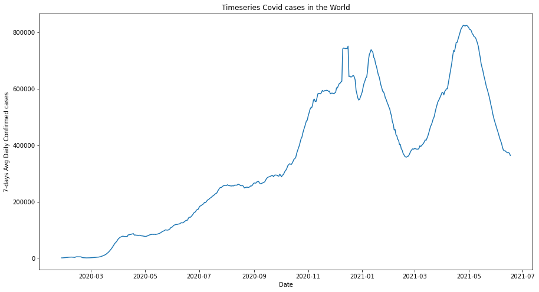

```python
world_fig = plot_data(timeseries_df,"daily_confirmed",all_countries = True,smooth = True);
world_fig
```

# World curve description

1- we can see the wave strength is increasing over time.

2- Waves Describtion:

**Start:** Feb 2020 (based on the data in our hands)

**Stabilize high:** from about mid april 2020 to mid may 2020

**Continous growth:** from mid may 2020 to Aug 2020

**Stabilize high:** from about Aug 2020 to October 2020 to Dec 2020

**Strong growth:** from October 2020

**Stabilize high:** till about mid Jan 2021

**First depression:** from mid Jan 2021 to end Feb 2021

**Stabilize low:** from end Feb 2021 to mid march 2021

**Stronger growth:** from march 2021 to may 2021

**Second depression:** from may 2021 till now

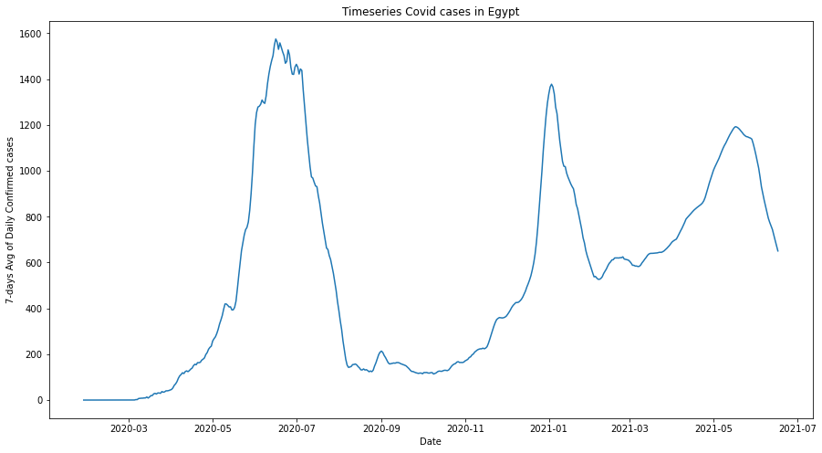

```python
eg_fig = plot_data(timeseries_df,"daily_confirmed",country = "Egypt",all_countries = False,smooth = True)
eg_fig
```

# Egypt curve description

1- we can see the wave strength is decreasing over time.

2- Waves Describtion:

**Start:** March 2020

**First growth:** till mid june 2020

**First depression:** from mid Jun 2020 to early Aug 2020

**Stabilize low:** till Nov 2020

**Second growth:** from Nov 2020 to Jan 2021

**Second depression:** from Jan 2021 to Feb 2021

**Stabilize low:** till April 2021

**Third growth:** from April 2021 to mid may 2021

**Third depression:** from mid may 2021 till now

### lets give a look on other countries

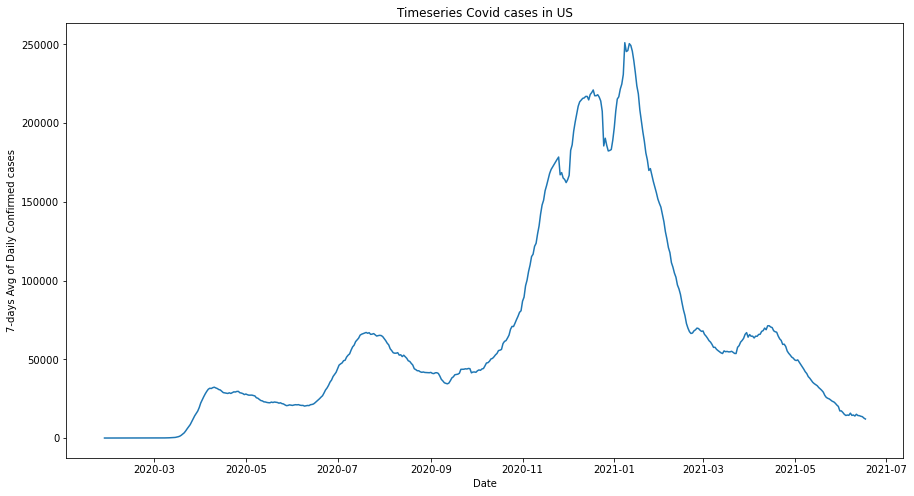

```python
US_fig = plot_data(timeseries_df,"daily_confirmed",country = "US",all_countries = False,smooth = True)
US_fig
```

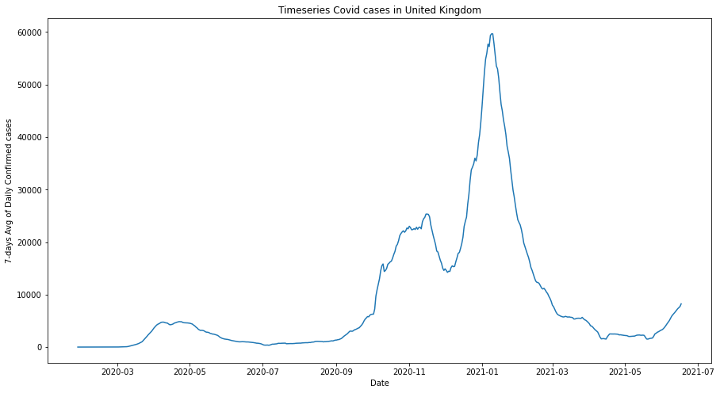

```python
United_kingdom_fig = plot_data(timeseries_df,"daily_confirmed",country = "United Kingdom",all_countries = False,smooth = True)
United_kingdom_fig
```

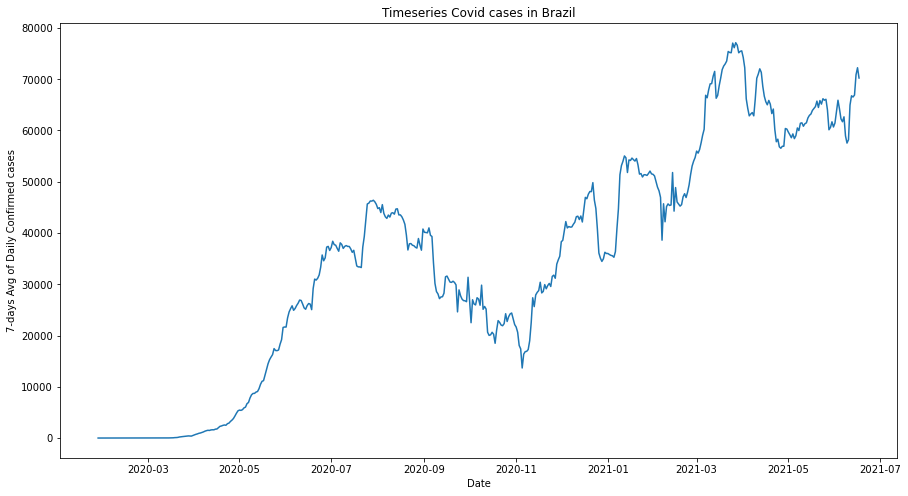

```python
Brazil_fig = plot_data(timeseries_df,"daily_confirmed",country = "Brazil",all_countries = False,smooth = True)
Brazil_fig
```

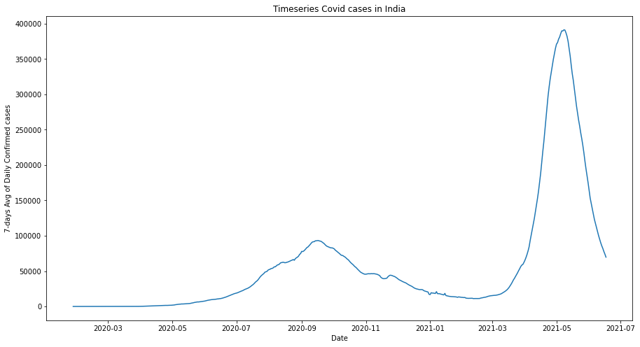

```python
India_fig = plot_data(timeseries_df,"daily_confirmed",country = "India",all_countries = False,smooth = True)
India_fig
```

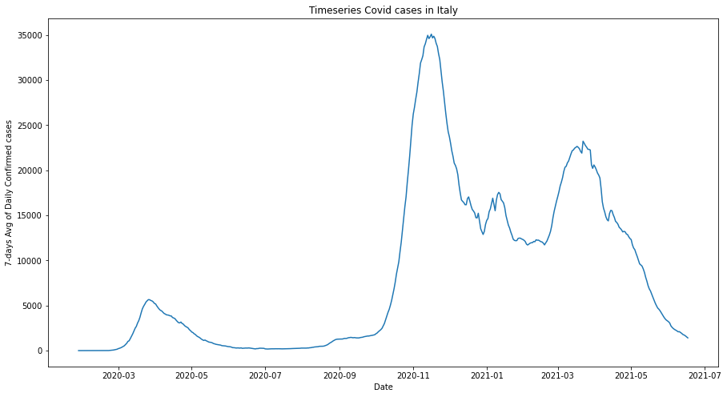

```python
Italy_fig = plot_data(timeseries_df,"daily_confirmed",country = "Italy",all_countries = False,smooth = True)
Italy_fig
```

## Create a summary function to see more detials about average cases in each month

```python
def country_summary(timeseries_df,country,variable):
        """

         A Function that returns 5 plots of choosen country summerizing choosen variable
         and answering:

         1 what is the timeseries distribution of the variable?
         2- which month has higher cases and which has lower?

        timeseries_df
        country: country name
        variable: valid for daily_confirmed,daily_recoverd,daily_deaths,etc...

        """
        country_df = timeseries_df[timeseries_df["country"] == country].copy()

#         plt.figure(figsize=(8,4))

        country_df[variable] = country_df[variable].rolling(7).mean()

        plt.figure(figsize=(30,20))
        plt.subplot(3,2,1)
        sns.lineplot(x =country_df.date , y =country_df[variable])
        plt.title("Timeseries of {} cases in {}".format(variable.replace("_", " "),country))
        plt.xlabel("Date")
        plt.ylabel(variable.title().replace("_", " ") + " Cases")

        plt.figure(figsize=(15,15))
        plt.subplot(3,2,3)
        sns.boxplot(x='month', y=variable, data=country_df)
        plt.title("Month's {} Cases Distribution in {}".format(variable.replace("_", " "),country))
        plt.xlabel("Month")
        plt.ylabel("{} cases".format(variable.title().replace("_", " ")));


        plt.subplot(3,2,4)
        sns.boxplot(x='month', y=variable,hue= "year", data=country_df);
        plt.title("Month's distribution of {} Cases per year in {}".format(variable.replace("_", " "),country))
        plt.xlabel("Month")
        plt.ylabel("{} cases".format(variable.title().replace("_", " ")));


        plt.subplot(3,2,5)
        sns.pointplot(data=country_df, x='month', y=variable,hue = "year")
        plt.title("Average {} Cases per Month in {}".format(variable.title().replace("_", " "),country))
        plt.xlabel("Month")
        plt.ylabel('Avg. {} cases'.format(variable.title().replace("_", " ")));


        plt.subplot(3,2,6)
        sns.histplot(data=country_df, x='month', y=variable)
        plt.title("Month's {} Cases Distribution in {}".format(variable.title().replace("_", " "),country))
        plt.xlabel("Month")
        plt.ylabel('{} cases'.format(variable.title().replace("_", " ")))
```

### US summary

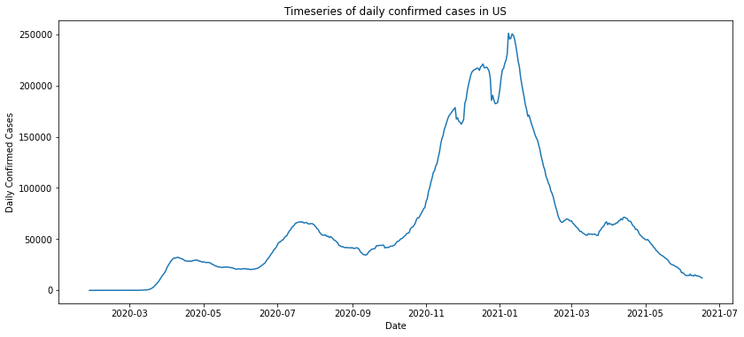

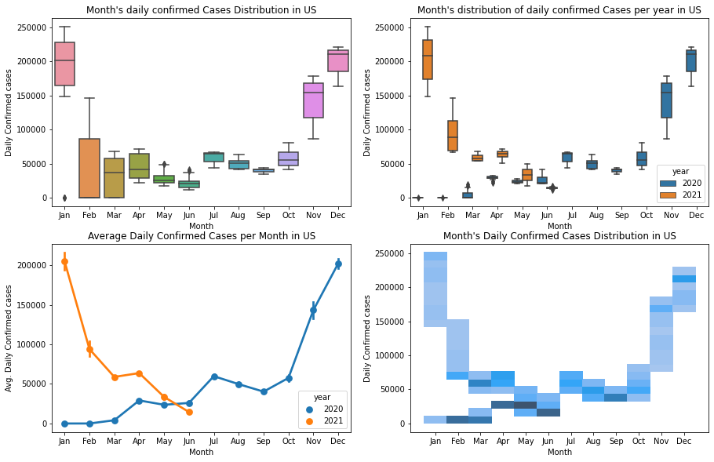

```python
country_summary(timeseries_df,"US","daily_confirmed")
```